# 20231023_metricSims

#### 60%

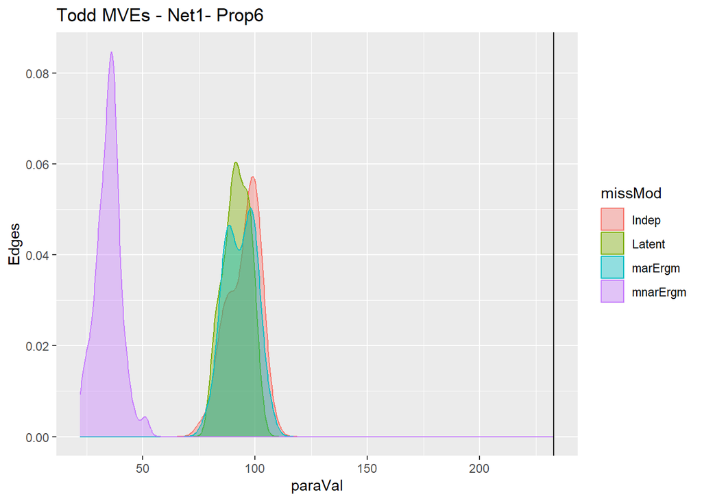

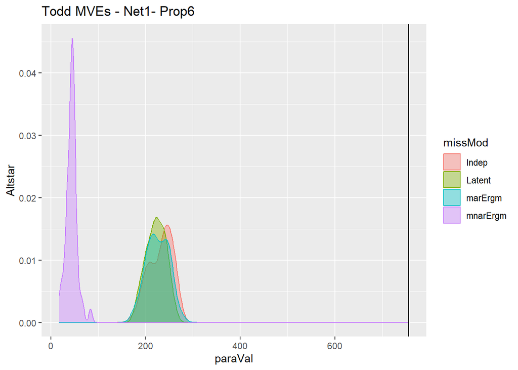

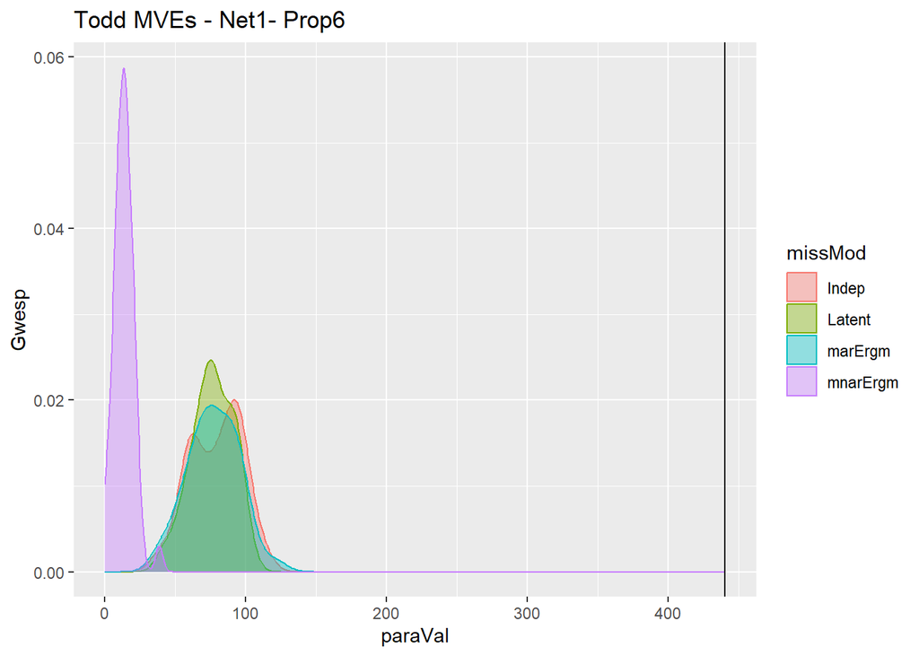

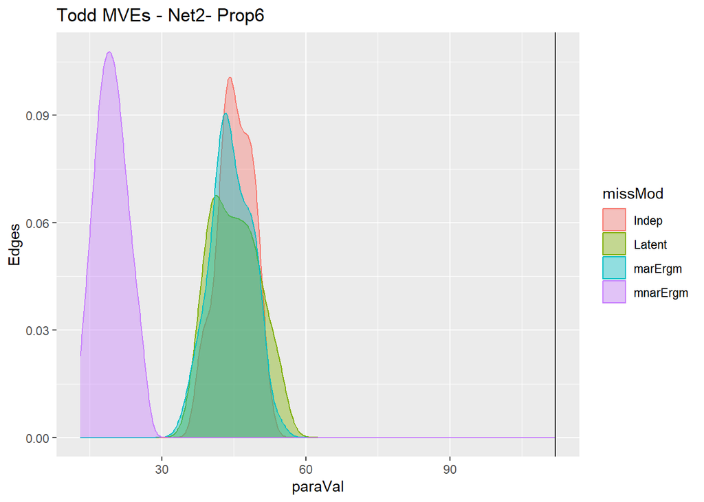

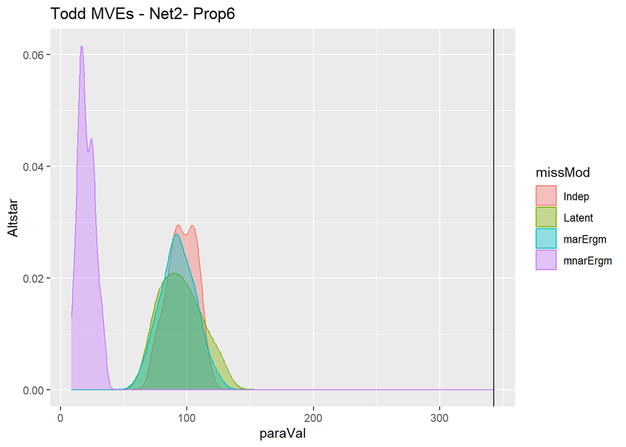

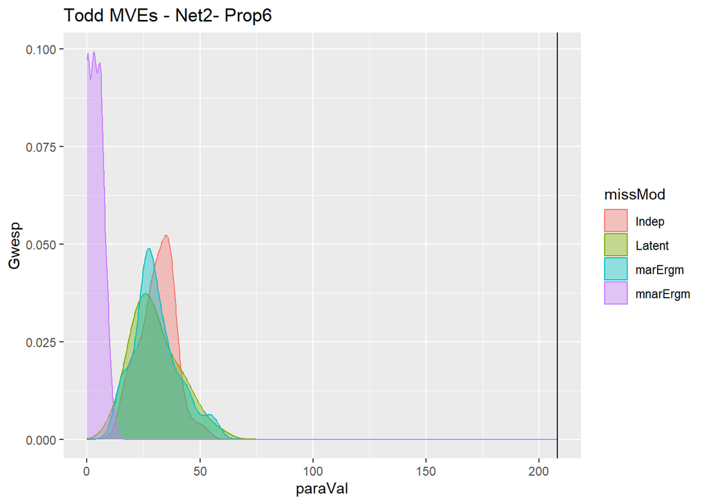

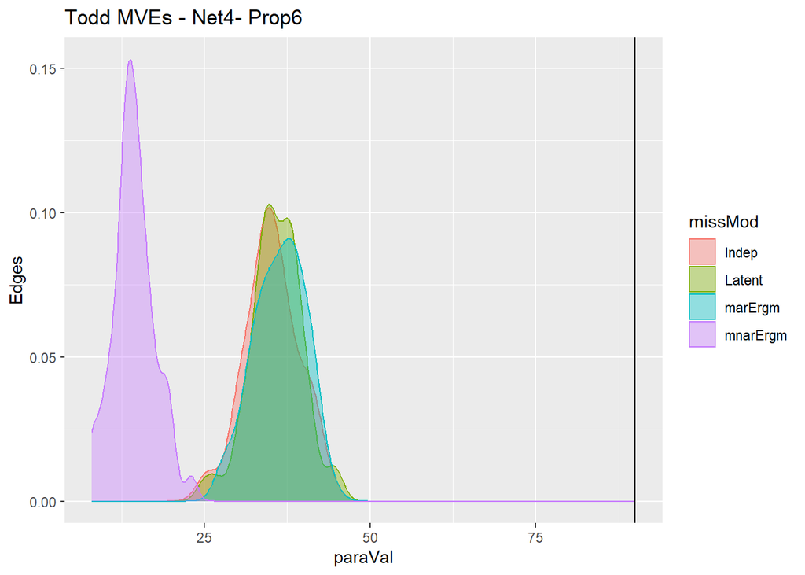

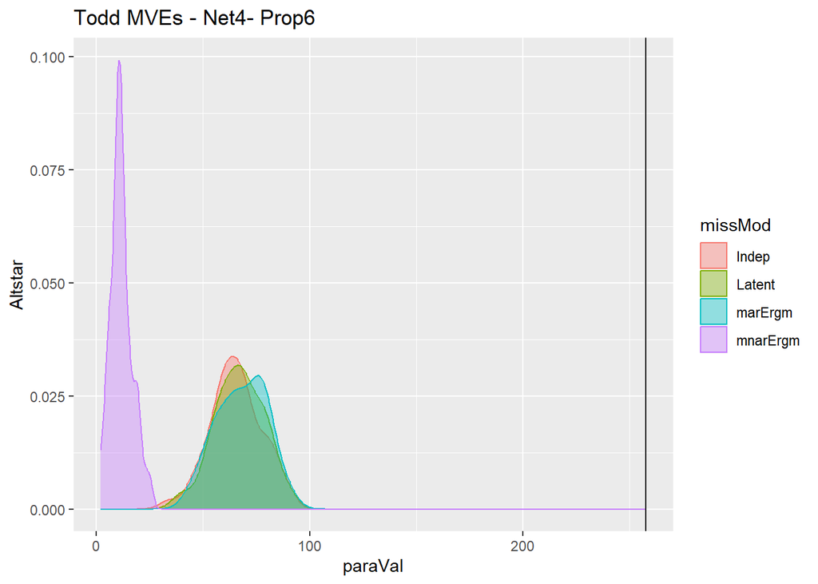

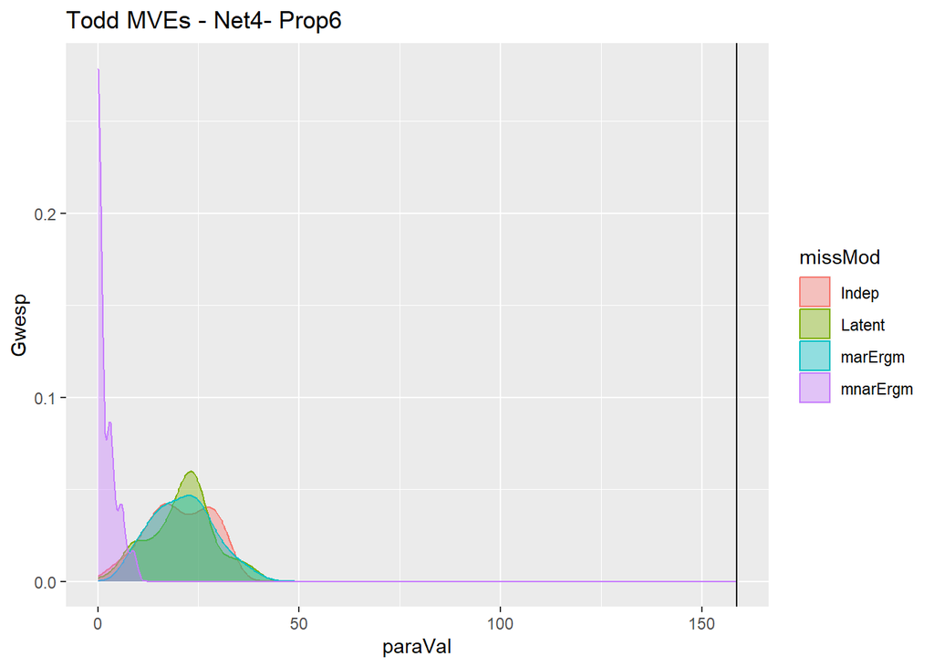

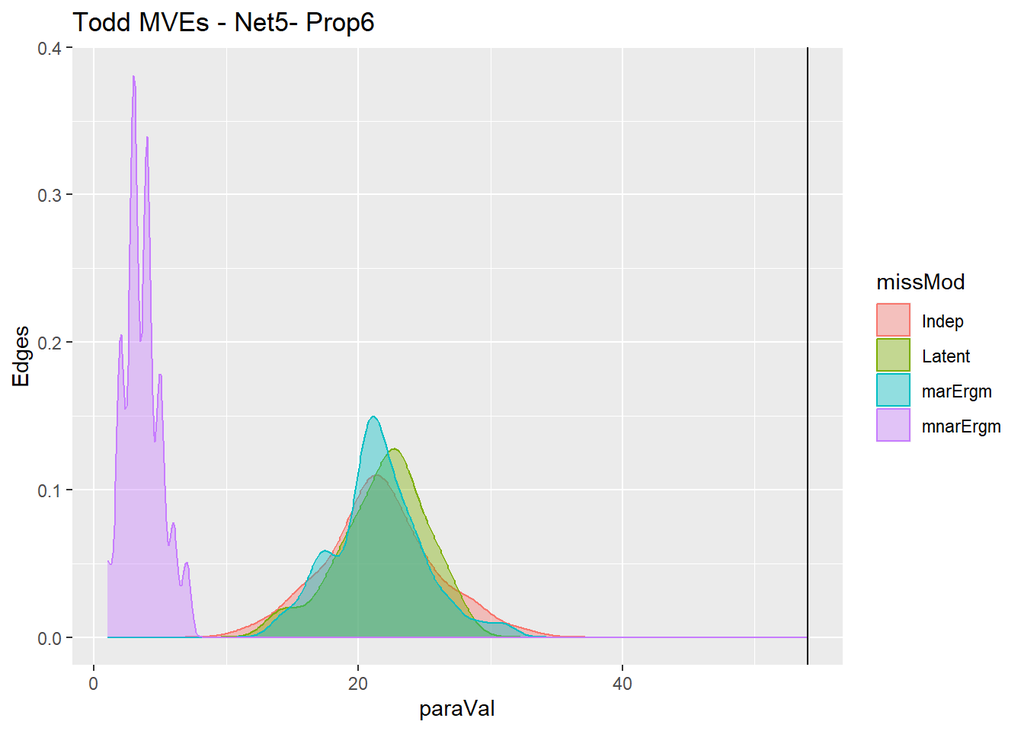

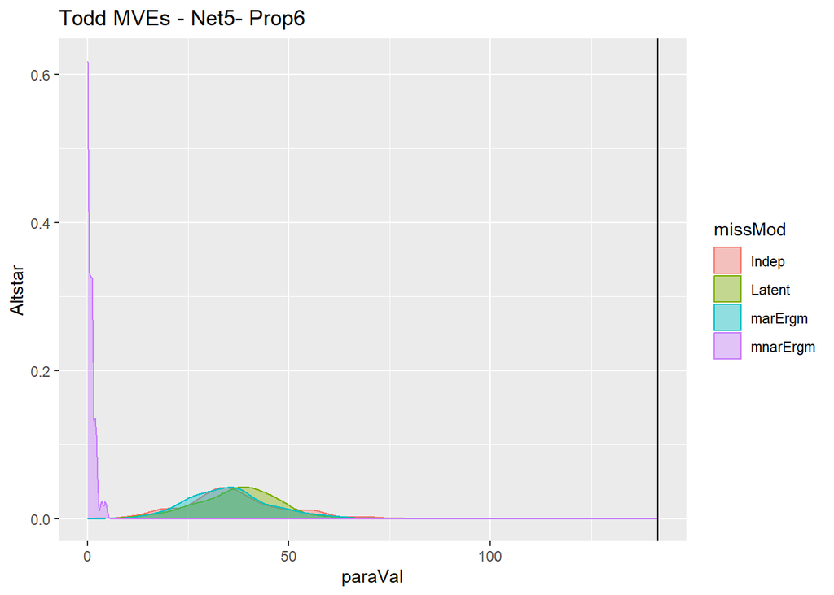

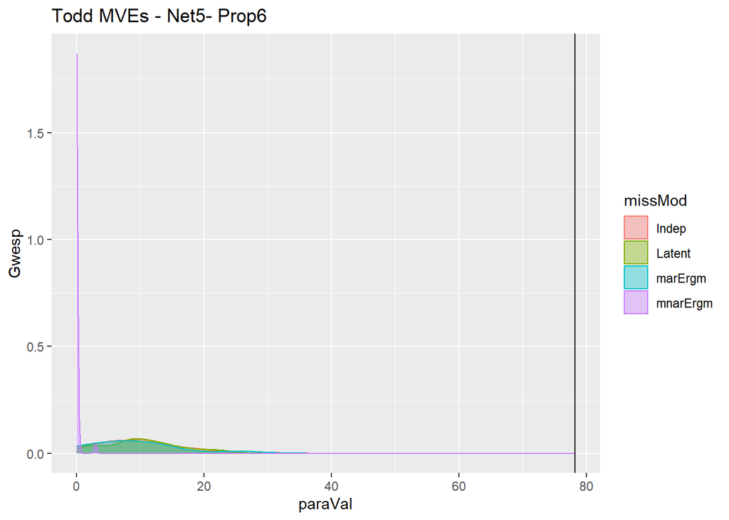

[3 more figures not shown]

```r
# TODO: choose a missingness proportion (1, 3.5 or 6)
chunkMissProp = 6

# now looping with a specific vector of applicable networks
# TODO: specify the UCINet networks for the chunk, these are networks with enough re-estimations
chunkNetworks = c(1, 2, 4, 5, 6)

# read files
# these are indep/mar/latent
load(here("Output", "20230814_simMissNets", paste("20231024_chosenMissNets_prop", chunkMissProp,".RData", sep = "")))

# with the list of missingness matrices, apply them to the true adjmat to deplete
# usingt he degrade adj function as a small shortcut
# a doozy of code line, but mostly due to the nested-list structure
# saving as Todd because we're calculating metrics

# for the whole compiled list of missingness matrices,
# go though all of the missingness models
# choose only the specified network,
# and for all the missingness matrices in them, degrade the specified true network (which is saved as a matrix)


# the master todd plot data
toddMvpPlotData = data.frame(paraVal = c(), paraName = c(), missMod = c(), net = c())

# loop start
for(chunkInd in 1:length(chunkNetworks)){

  # choose some network
  chosenNetInd = chunkNetworks[chunkInd]
  trueAdj = adjMatList[[chosenNetInd]]

  # degrade the adjlist with the simulated missingness matrices
  degradedAdjList = lapply(compiledMissNets, function(chosenMissMod){
    lapply(chosenMissMod[[chosenNetInd]], function(chosenMissAdj){
      degradeAdj(trueNet = trueAdj, missAdj = chosenMissAdj, missSave = 0)})})

  # turn all of them into networks
  degradedNetList = lapply(degradedAdjList, FUN = function(chosenMissMod){
    lapply(chosenMissMod, FUN = as.network, directed = FALSE)})

  # # then calculate metrics
  # degradedNetMetrics = lapply(degradedNetList, FUN = function(chosenMissMod){
  #   lapply(chosenMissMod, netMetrics)})


  # specify model
  chosenModel = "edges + altkstar(2, fixed = TRUE) + gwesp(decay = log(2), fixed = TRUE)"

  # specific branch for network 6
  if( chosenNetInd == 6 ){

    # specify the model
    chosenModel = "edges + altkstar(2, fixed = TRUE) + gwesp(decay = log(2), fixed = TRUE) +  nodecov('Age') +
      absdiff('Age') + nodecov('Arrests') + absdiff('Arrests') + nodecov('Convictions') + absdiff('Convictions') + nodematch('Prison') +
      nodematch('Birthplace')"

    # add in the covariates to all the network objects

    for(chosenMissMod in 1:length(degradedNetList)){
  degradedNetList[[chosenMissMod]] =  lapply(degradedNetList[[chosenMissMod]], FUN = function(chosenNet){
      set.vertex.attribute(x = chosenNet, attrname = "Age", value = londonGangsAtt$Age)
      set.vertex.attribute(x = chosenNet, attrname = "Arrests", value = londonGangsAtt$Arrests)
      set.vertex.attribute(x = chosenNet, attrname = "Birthplace", value = londonGangsAtt$Birthplace)
      set.vertex.attribute(x = chosenNet, attrname = "Convictions", value = londonGangsAtt$Convictions)
      set.vertex.attribute(x = chosenNet, attrname = "Prison", value = londonGangsAtt$Prison)

      })
    }

  }

  # and MVPs
  degradedMvpList = lapply(degradedNetList, FUN = function(chosenMissMod){
    lapply(chosenMissMod, FUN = meanValPar, model = chosenModel)})



  # miss models
  missMods = c("Indep", "marErgm", "Latent", "mnarErgm")

  for(chosenMissMod in 1:4){

    # chosen miss mod string
    chosenModString = missMods[chosenMissMod]

    # unlist
    toddUnlisted = unlist(degradedMvpList[[chosenMissMod]])

    uniqueParaNames = unique(names(toddUnlisted))

    # grab all the edges
    toddEdges = toddUnlisted[names(toddUnlisted) == uniqueParaNames[1]]

    # altstars
    toddAltstar = toddUnlisted[names(toddUnlisted) == uniqueParaNames[2]]

    # gwesps
    toddGwesp = toddUnlisted[names(toddUnlisted) == uniqueParaNames[3]]


    # using Todd (multiple miss mods)
    tempPlot = data.frame(paraVal = c(toddEdges, toddAltstar, toddGwesp),
                          paraName = c(rep("edges", length(toddEdges)), rep("Altstar", length(toddAltstar)), rep("gwesp", length(toddGwesp))),
                          missMod = rep(chosenModString, sum(length(toddEdges), length(toddAltstar), length(toddGwesp))),
                          net = rep(chosenNetInd, 150))

    # bind
    toddMvpPlotData = rbind(toddMvpPlotData, tempPlot)

  }

}

### Plotting section
# true Mvp list
trueMvpList = list()

for(chunkInd in 1:length(chunkNetworks)){

  # choose some network
  chosenNetInd = chunkNetworks[chunkInd]

  # find the true MVP for the given network
    # change the 'true' network depending on the chosen network index
  trueAdj = adjMatList[[chosenNetInd]]

  # turn into a network obj
  trueNet = as.network(trueAdj, directed = FALSE)

  if(chosenNetInd == 6){
    # add in the attributes for this network/model spec
      trueNet %v% 'Age' = londonGangsAtt$Age
      trueNet %v% 'Arrests' = londonGangsAtt$Arrests
      trueNet %v% 'Birthplace' = londonGangsAtt$Birthplace
      trueNet %v% 'Convictions' = londonGangsAtt$Convictions
      trueNet %v% 'Prison' = londonGangsAtt$Prison
  }


  # plot for the 'true' MVP, put in a list for later use
  chosenModel = "edges + altkstar(2, fixed = TRUE) + gwesp(decay = log(2), fixed = TRUE)"

  # since net 6 is different,
  if(chosenNetInd == 6){
    chosenModel = "edges + altkstar(2, fixed = TRUE) + gwesp(decay = log(2), fixed = TRUE) +  nodecov('Age') +
    absdiff('Age') + nodecov('Arrests') + absdiff('Arrests') + nodecov('Convictions') + absdiff('Convictions') + nodematch('Prison') +
    nodematch('Birthplace')"
  }

  chunkTrueMvp = meanValPar(net = trueNet,
                            model = chosenModel)

  trueMvpList[[chunkInd]] = chunkTrueMvp

  # wrangle specific parts of the data
  toddMvpPlotSubset = toddMvpPlotData %>%
    filter(paraName == "edges" & net == chosenNetInd)

  print(ggplot(toddMvpPlotSubset, aes(x = paraVal, colour = missMod, fill = missMod)) +
   # geom_histogram(alpha = 0.4, position = "identity", binwidth = 1) +
    geom_density(alpha = 0.4) +
    geom_vline(xintercept = trueMvpList[[chunkInd]][1]) +
    ylab(paste("Edges")) +
    ggtitle(label = paste("Todd MVEs - Net", chosenNetInd, "- Prop", chunkMissProp, sep = "")))

  toddMvpPlotSubset = toddMvpPlotData %>%
    filter(paraName == "Altstar" & net == chosenNetInd)

  print(ggplot(toddMvpPlotSubset, aes(x = paraVal, colour = missMod, fill = missMod)) +
   # geom_histogram(alpha = 0.4, position = "identity", binwidth = 1) +
    geom_density(alpha = 0.4) +
    geom_vline(xintercept = trueMvpList[[chunkInd]][2]) +
    ylab(paste("Altstar")) +
    ggtitle(label = paste("Todd MVEs - Net", chosenNetInd, "- Prop", chunkMissProp, sep = "")))

  toddMvpPlotSubset = toddMvpPlotData %>%
    filter(paraName == "gwesp" & net == chosenNetInd)

  print(ggplot(toddMvpPlotSubset, aes(x = paraVal, colour = missMod, fill = missMod)) +
   # geom_histogram(alpha = 0.4, position = "identity", binwidth = 1) +
    geom_density(alpha = 0.4) +
    geom_vline(xintercept = trueMvpList[[chunkInd]][3]) +
    ylab(paste("Gwesp")) +
    ggtitle(label = paste("Todd MVEs - Net", chosenNetInd, "- Prop", chunkMissProp, sep = "")))


}
```

### Peter MVPs

#### 10%

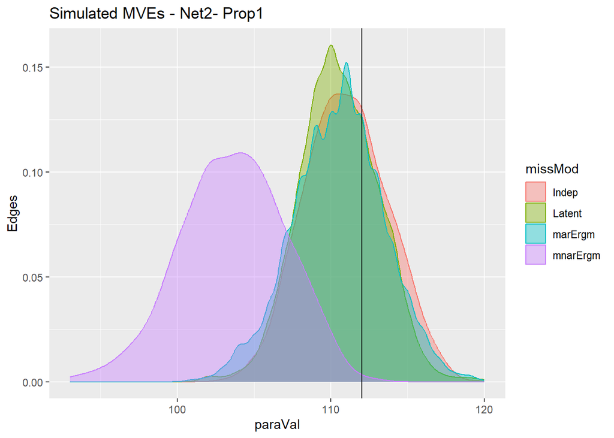

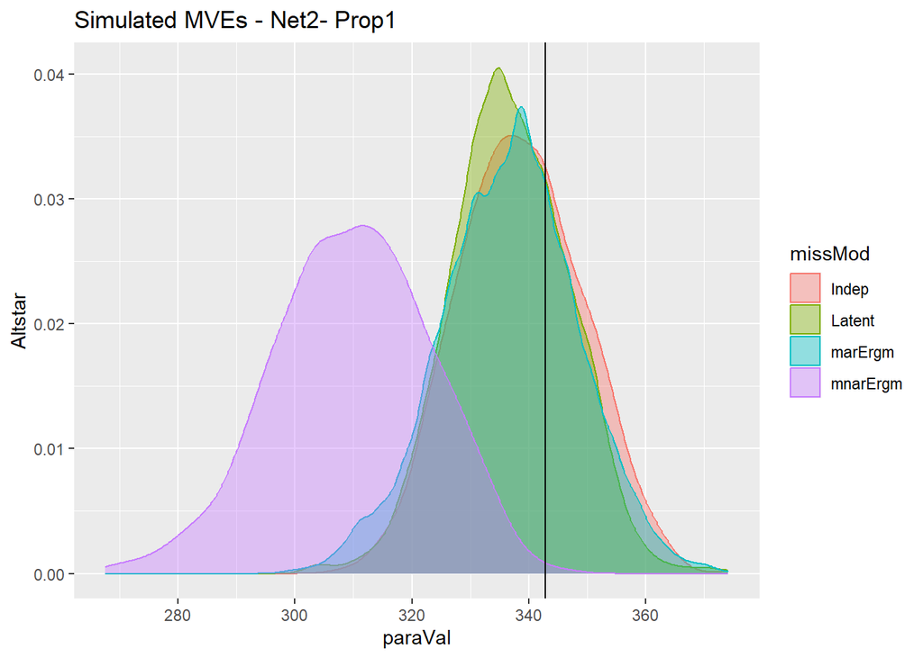

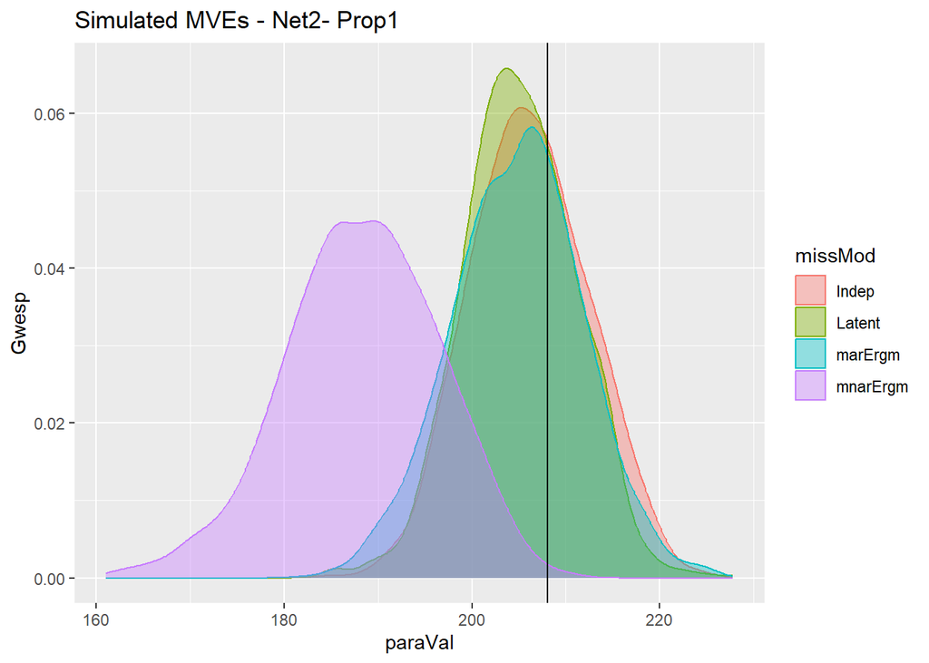

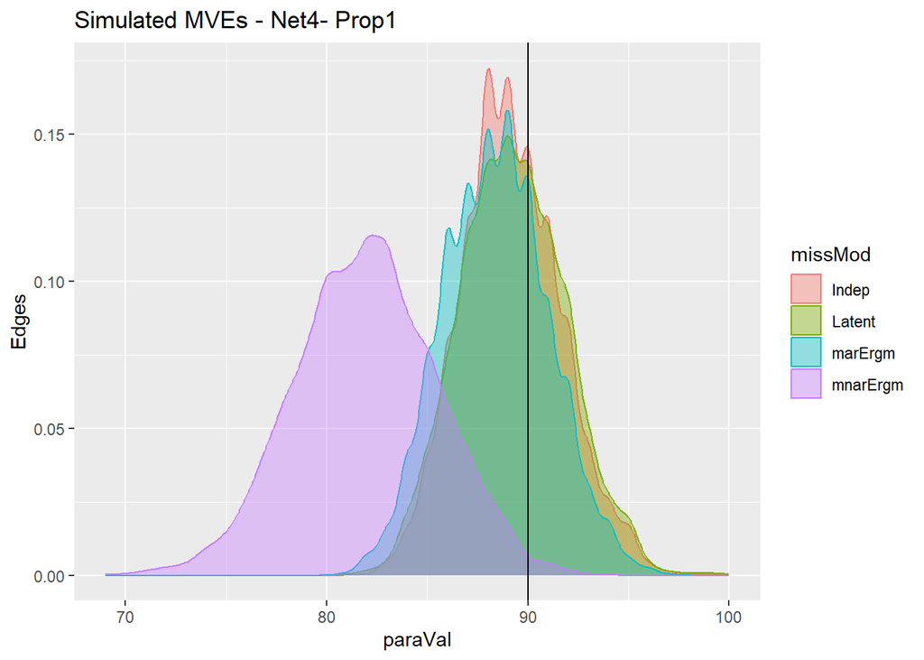

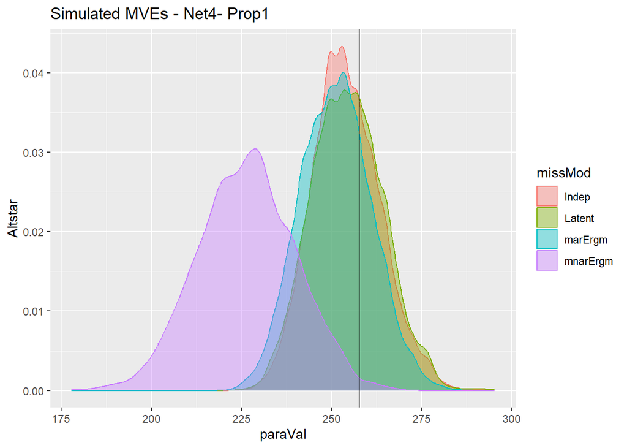

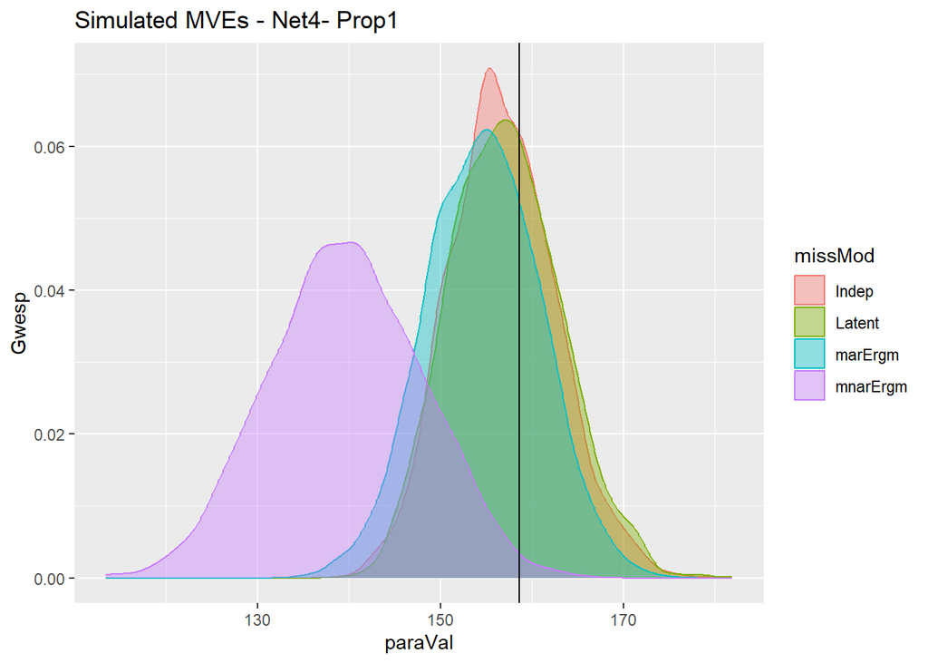

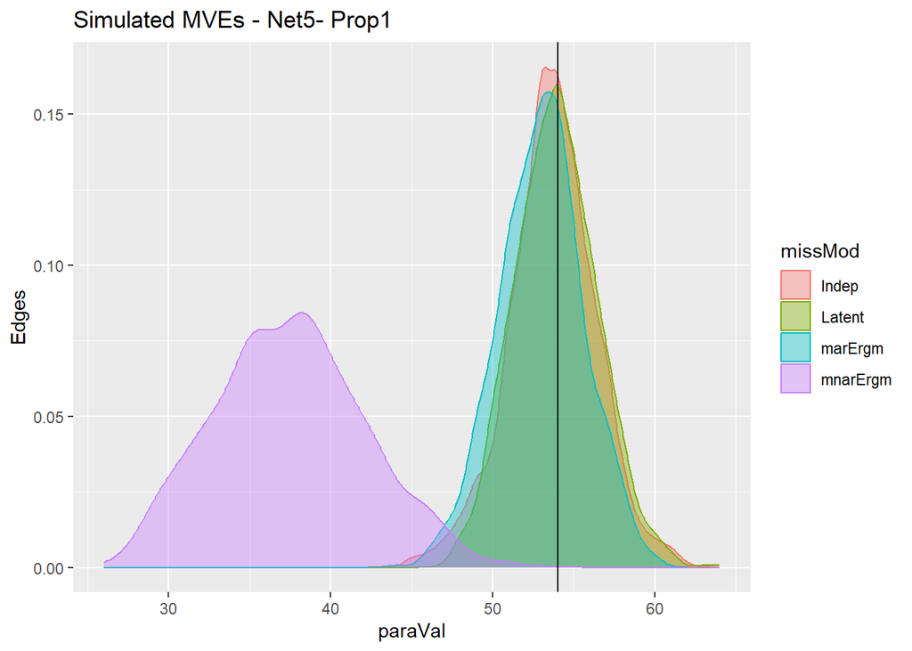

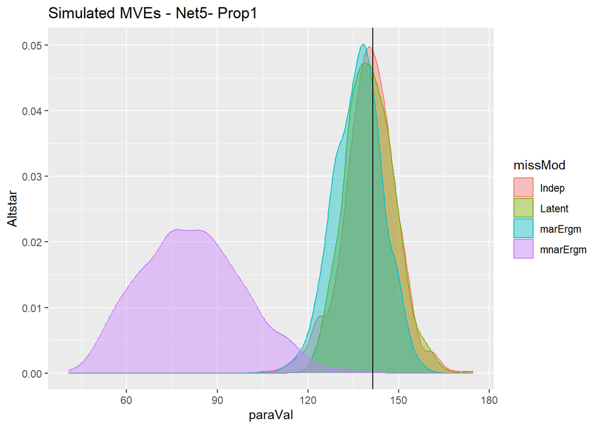

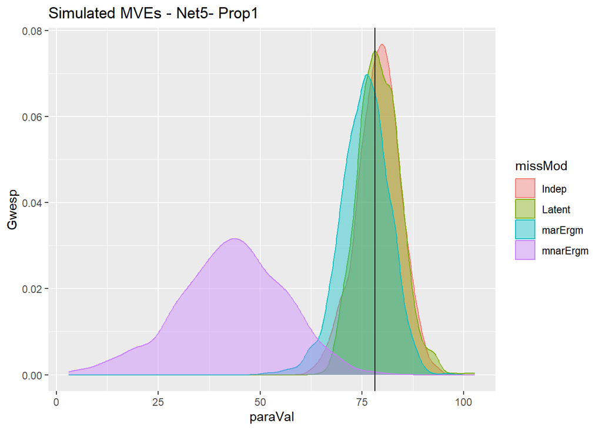

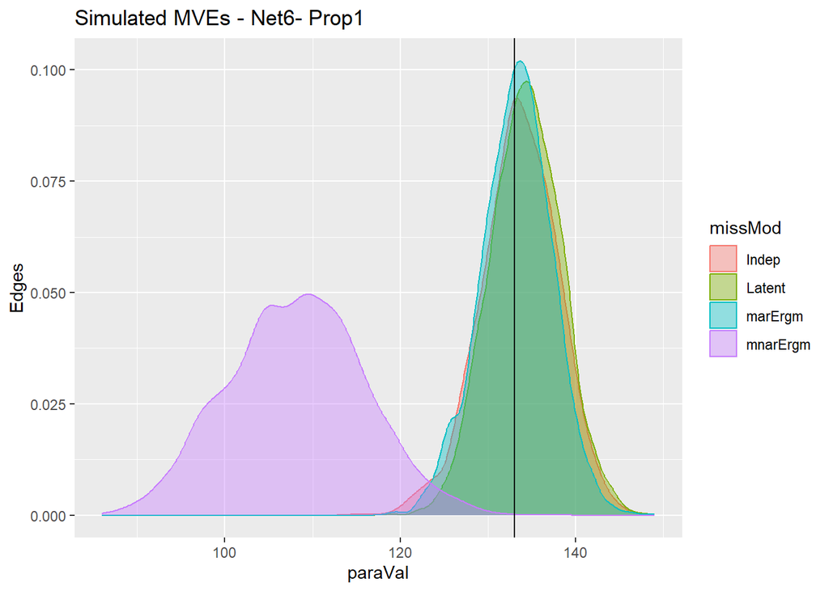

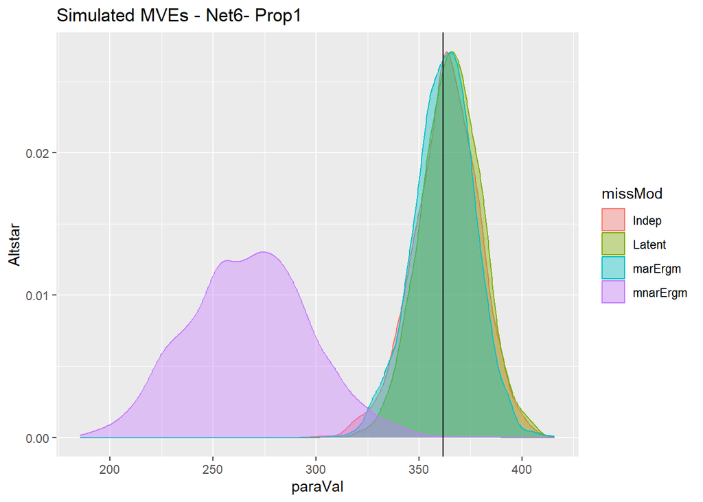

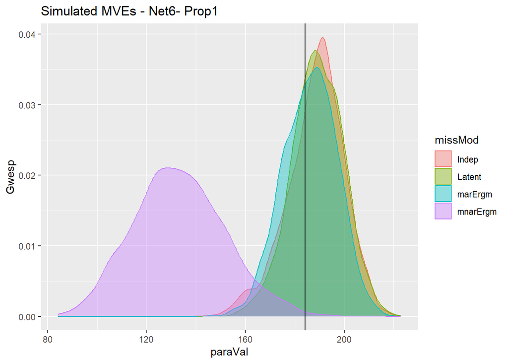

```r
# the peter output list
outputList = list.files(here("Output", "20230825_simMissReest", "Peter"))

# TODO: choose a missingness proportion (1, 3.5 or 6)
chunkMissProp = 1

# load the right set of missingness matrices
load(here("Output", "20230814_simMissNets", paste("20231024_chosenMissNets_prop", chunkMissProp,".RData", sep = "")))

# now looping with a specific vector of applicable networks
# TODO: specify the UCINet networks for the chunk, these are networks with enough re-estimations
chunkNetworks = c(2, 4, 5, 6)

# TODO: vector of file names for regex
chunkRdataNames = c("20230814_missNetReest_net",
                    "20230814_missNetReest_net",
                    "20230814_missNetReest_net",
                    "20231010_missNetReest_net")

chunkMnarNames = c("20231011_missErgmNetReest_Miss",
                   "20231011_missErgmNetReest_Miss",
                   "20231011_missErgmNetReest_Miss",
                   "20231011_missErgmNetReest_Miss")

# peter mvp list and the list for missingness model identifiers
peterMvpList = list()
peterMvpMissModList = list()

# loop for all chosen networks
for(chunkInd in 1:length(chunkNetworks)){

  # make sure the re-estimation lists are empty in the beginning
  modelResList = list()
  missModelList = list()
  propMissList = list()
  trialIndList = list()

  # set a specific index for the network
  chosenNetInd = chunkNetworks[chunkInd]

  # change the 'true' network depending on the chosen network index
  trueAdj = adjMatList[[chosenNetInd]]

  # file list for the chosen network index
  chosenNetOutFiles = grep(paste(chunkRdataNames[chunkInd], chosenNetInd, sep =""), outputList)

  ## regex the MNAR files
  chosenMnarOutFiles = grep(paste(chunkMnarNames[chunkInd], "Peter", "_net", chosenNetInd, sep = ""), outputList)

  # combine the two indices
  combinedNetOutList = c(chosenNetOutFiles, chosenMnarOutFiles)

  # check to make sure there aren't any duplicates
  if( length(unique(combinedNetOutList)) != length(combinedNetOutList)){
    stop("Duplicate re-estimation datafiles! BAD.")
  }

  # loop to load
  chosenNetOutList = outputList[combinedNetOutList]

  for(fileInd in 1:length(chosenNetOutList)){

    # load all files
    load(here("Output", "20230825_simMissReest", "Peter", chosenNetOutList[fileInd]))

    # suppress these version difference warnings.
    suppressWarnings({
    modelResList[[fileInd]] = modelres$coefficients
    })

    # slight difference for the chosenMnarOutFiles because missModelList[[fileInd]] = always 4 (let 2 be mar ergm, 4 be mnar ergm)

    # this branch *should* be setting the miss model to 4 if they were regexed to be a part of the mnar list.
    if(combinedNetOutList[fileInd] %in% chosenMnarOutFiles){
     missModelList[[fileInd]] = 4
    } else {
     missModelList[[fileInd]] = as.integer(sub(".*?_missModel.*?(\\d+).*", "\\1", chosenNetOutList[[fileInd]]))
    }

    # propmiss should be the same
    propMissList[[fileInd]] = as.integer(sub(".*?_prop.*?(\\d+).*", "\\1", chosenNetOutList[[fileInd]]))


    # trial ind
    trialIndList[[fileInd]] = as.integer(sub(".*?_trial.*?(\\d+).*", "\\1", chosenNetOutList[[fileInd]]))

  }

#####

  # miss model labels
  missModelLabels = c("Indep", "marErgm", "Latent", "mnarErgm")

  # peterSims needs to be a list
  peterSimList = list()

  # a diagnostic check for the miss models chosen
  peterSimMissModList = list()

  # an absolute trial index because these lists are not going to have similar lengths.
  trial = 1

  # describe the chosen missingness matrix as a series of specific indices, net is specified above
  for(chosenMissModel in 1:length(missModelLabels)){

  # the lists contain files for all the missingness proportions, so they need to be indexed
  chosenReest = (propMissList == chunkMissProp) & (missModelList == chosenMissModel)

  modelResChosenReestList = modelResList[chosenReest]
  trialIndChosenReestList = trialIndList[chosenReest]
  missModelChosenReestList = missModelList[chosenReest]


  # OKAY, for a given missingness model, which will still iterate through all four,
  chunkTrialInds = unlist(trialIndChosenReestList)

    for(chosenTrialInd in 1:length(chunkTrialInds)){

      # and choose, needs the ACTUAL trial index, not the index for the object in the list
      chosenMissAdj = compiledMissNets[[chosenMissModel]][[chosenNetInd]][[chunkTrialInds[[chosenTrialInd]]]]

      # now for Peters, we need to manually simulate the mean value estimates.
      degradedAdj = degradeAdj(trueNet = trueAdj, missAdj = chosenMissAdj)

      # now as a network
      degradedNet = as.network(degradedAdj, directed = FALSE)

      # miss edge list
      missEdgeList = as.edgelist(as.network(chosenMissAdj, directed = FALSE))

      # model spec depends on the network
      chosenModel = degradedNet ~ edges + altkstar(2, fixed = TRUE) + gwesp(decay = log(2), fixed = TRUE)

      # if network 6, change to:
      if(chosenNetInd == 6){

      # make sure to add in attributes
      # add in attributes
        degradedNet %v% 'Age' = londonGangsAtt$Age
        degradedNet %v% 'Arrests' = londonGangsAtt$Arrests
        degradedNet %v% 'Birthplace' = londonGangsAtt$Birthplace
        degradedNet %v% 'Convictions' = londonGangsAtt$Convictions
        degradedNet %v% 'Prison' = londonGangsAtt$Prison

        chosenModel = degradedNet ~ edges + altkstar(2, fixed = TRUE) + gwesp(decay = log(2), fixed = TRUE) +
                                    nodecov('Age') +
                                    absdiff('Age') +
                                    nodecov('Arrests') +
                                    absdiff('Arrests') +
                                    nodecov('Convictions') +
                                    absdiff('Convictions') +
                                    nodematch('Prison') +
                                    nodematch('Birthplace')


      }

      peterSim = simulate(object = chosenModel,
                          constraints = ~fixallbut(missEdgeList),
                          coef = modelResChosenReestList[[chosenTrialInd]],
                          control=control.simulate(
                                    MCMC.burnin=20000,
                                    MCMC.interval=100), nsim=50)

      # shove in a list
      peterSimList[[trial]] = peterSim

      # something to keep track of which missingness model it is
      peterSimMissModList[[trial]] = chosenMissModel

      # iterate the trial index
      trial = trial + 1

    }

  }


  # and calculate MVPs

  chosenModel = "edges + altkstar(2, fixed = TRUE) + gwesp(decay = log(2), fixed = TRUE)"

  if(chunkInd == 6){
    chosenModel = "edges + altkstar(2, fixed = TRUE) + gwesp(decay = log(2), fixed = TRUE) +  nodecov('Age') +
  absdiff('Age') + nodecov('Arrests') + absdiff('Arrests') + nodecov('Convictions') + absdiff('Convictions') + nodematch('Prison') +
  nodematch('Birthplace')"
  }


  tempPeterMvpList = lapply(peterSimList, FUN = function(chosenMissMod){
      lapply(chosenMissMod, FUN = meanValPar, model = chosenModel)})

  peterMvpList[[chunkInd]] = tempPeterMvpList
  peterMvpMissModList[[chunkInd]] = peterSimMissModList

}

#### Plotting section

# the big master plot dataframe
peterMvpPlotData = data.frame(paraVal = c(), paraName = c(), missMod = c(), net = c())

# true Mvp list
trueMvpList = list()

for(chunkInd in 1:length(chunkNetworks)){

  # set a specific index for the network
  chosenNetInd = chunkNetworks[chunkInd]

  # change the 'true' network depending on the chosen network index
  trueAdj = adjMatList[[chosenNetInd]]

  # turn into a network obj
  trueNet = as.network(trueAdj, directed = FALSE)

  if(chosenNetInd == 6){
    # add in the attributes for this network/model spec
      trueNet %v% 'Age' = londonGangsAtt$Age
      trueNet %v% 'Arrests' = londonGangsAtt$Arrests
      trueNet %v% 'Birthplace' = londonGangsAtt$Birthplace
      trueNet %v% 'Convictions' = londonGangsAtt$Convictions
      trueNet %v% 'Prison' = londonGangsAtt$Prison
  }


  # plot for the 'true' MVP, put in a list for later use

  chosenModel = "edges + altkstar(2, fixed = TRUE) + gwesp(decay = log(2), fixed = TRUE)"

  # since net 6 is different,
  if(chosenNetInd == 6){
    chosenModel = "edges + altkstar(2, fixed = TRUE) + gwesp(decay = log(2), fixed = TRUE) +  nodecov('Age') +
    absdiff('Age') + nodecov('Arrests') + absdiff('Arrests') + nodecov('Convictions') + absdiff('Convictions') + nodematch('Prison') +
    nodematch('Birthplace')"
  }

  chunkTrueMvp = meanValPar(net = trueNet,
                            model = chosenModel)

  trueMvpList[[chunkInd]] = chunkTrueMvp


  # subset the right network's mvps
  chunkPeterMvp = peterMvpList[[chunkInd]]
  chunkPeterMvpMissMod = unlist(peterMvpMissModList[[chunkInd]])

  # miss models
  missMods = c("Indep", "marErgm", "Latent", "mnarErgm")

  for(chosenMissMod in 1:4){

    # chosen miss mod string
    chosenModString = missMods[chosenMissMod]

    # unlist
    tempPeterUnlisted = unlist(chunkPeterMvp[chunkPeterMvpMissMod == chosenMissMod])

    uniqueParaNames = unique(names(tempPeterUnlisted))

    # grab all the edges
    peterEdges = tempPeterUnlisted[names(tempPeterUnlisted) == uniqueParaNames[1]]

    # altstars
    peterAltstar = tempPeterUnlisted[names(tempPeterUnlisted) == uniqueParaNames[2]]

    # gwesps
    peterGwesp = tempPeterUnlisted[names(tempPeterUnlisted) == uniqueParaNames[3]]


    # using Todd (multiple miss mods)
    tempPlot = data.frame(paraVal = c(peterEdges, peterAltstar, peterGwesp),
                          paraName = c(rep("edges", length(peterEdges)), rep("Altstar", length(peterAltstar)), rep("gwesp", length(peterGwesp))),
                          missMod = rep(chosenModString, sum(length(peterEdges), length(peterAltstar), length(peterGwesp))),
                          net = rep(chosenNetInd, sum(length(peterEdges), length(peterAltstar), length(peterGwesp))))

    # bind
    peterMvpPlotData = rbind(peterMvpPlotData, tempPlot)

  }


  peterMvpPlotSubset = peterMvpPlotData %>%
    filter(paraName == "edges" & net == chosenNetInd)

  print(ggplot(peterMvpPlotSubset, aes(x = paraVal, colour = missMod, fill = missMod)) +
   # geom_histogram(alpha = 0.4, position = "identity", binwidth = 1) +
    geom_density(alpha = 0.4) +
    geom_vline(xintercept = trueMvpList[[chunkInd]][1]) +
    ylab(paste("Edges")) +
    ggtitle(label = paste("Simulated MVEs - Net", chosenNetInd, "- Prop", chunkMissProp, sep = "")))

  peterMvpPlotSubset = peterMvpPlotData %>%
    filter(paraName == "Altstar" & net == chosenNetInd)

  print(ggplot(peterMvpPlotSubset, aes(x = paraVal, colour = missMod, fill = missMod)) +
   # geom_histogram(alpha = 0.4, position = "identity", binwidth = 1) +
    geom_density(alpha = 0.4) +
    geom_vline(xintercept = trueMvpList[[chunkInd]][2]) +
    ylab(paste("Altstar")) +
    ggtitle(label = paste("Simulated MVEs - Net", chosenNetInd, "- Prop", chunkMissProp, sep = "")))

  peterMvpPlotSubset = peterMvpPlotData %>%
    filter(paraName == "gwesp" & net == chosenNetInd)

  print(ggplot(peterMvpPlotSubset, aes(x = paraVal, colour = missMod, fill = missMod)) +
   # geom_histogram(alpha = 0.4, position = "identity", binwidth = 1) +
    geom_density(alpha = 0.4) +
    geom_vline(xintercept = trueMvpList[[chunkInd]][3]) +
    ylab(paste("Gwesp")) +
    ggtitle(label = paste("Simulated MVEs - Net", chosenNetInd, "- Prop", chunkMissProp, sep = "")))

}
```

Note that for Peter MVP simulations (i.e., the Bayesian data augmentation equivalent), I need the natural parameter estimates for the coefficient values of the simulations (i.e., so that the missing tie variables are simulated with a model that is equivalent to the model for the obsrved tie variables).

What I need to do here is to go through the same regexes for the relevant re-estimated model results and match the trial indices to the relevant missingness model (for all the types of missingness models). The histogram at the end can be compiled with all the different networks (that should all be representative of a specfic missingness condition).

#### 35%

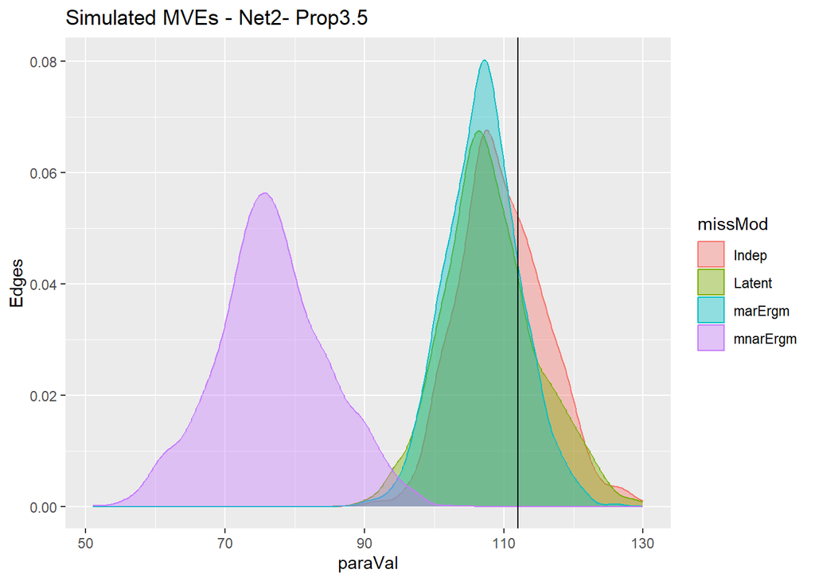

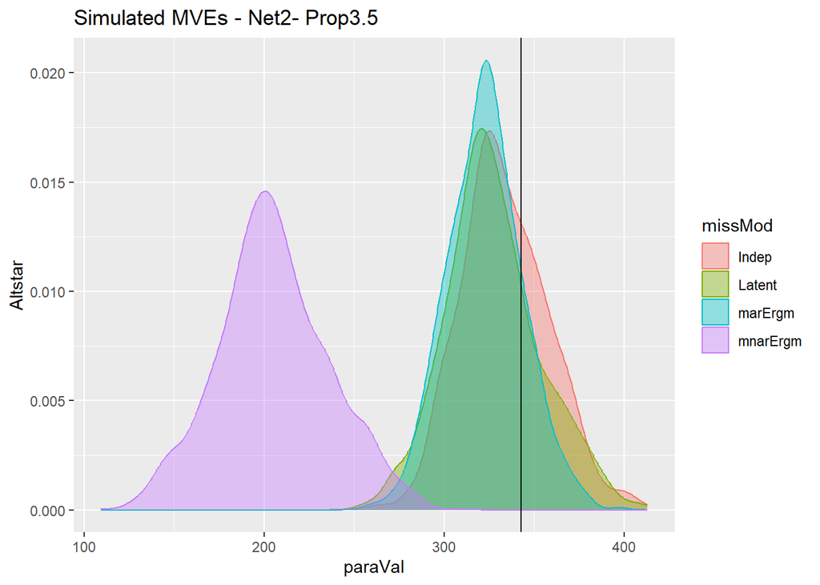

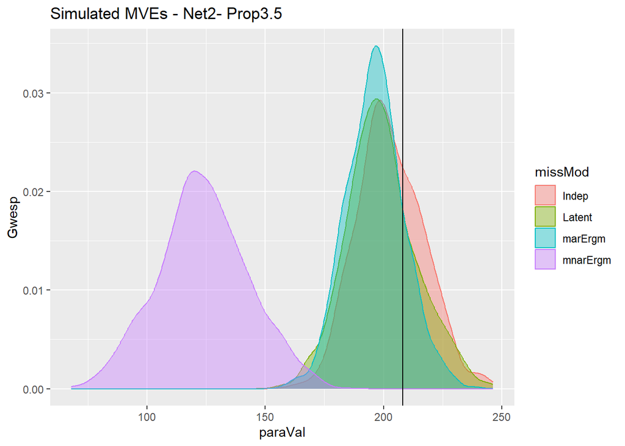

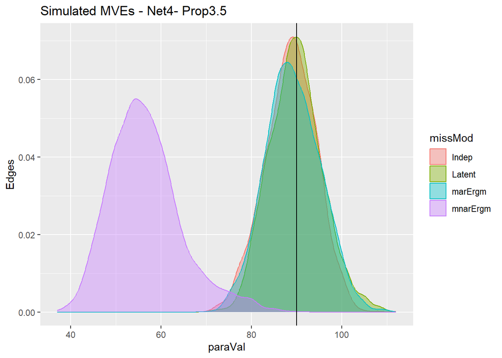

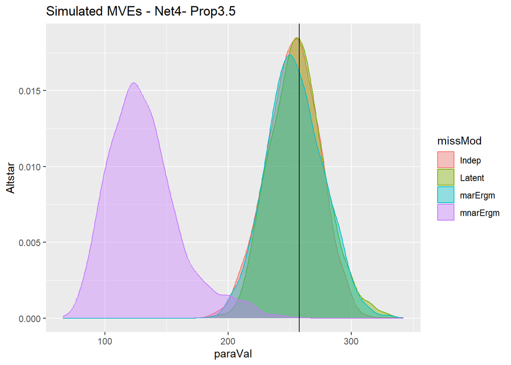

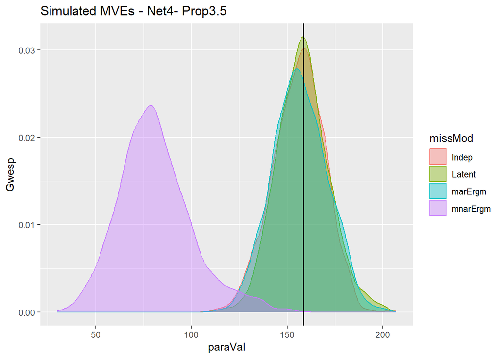

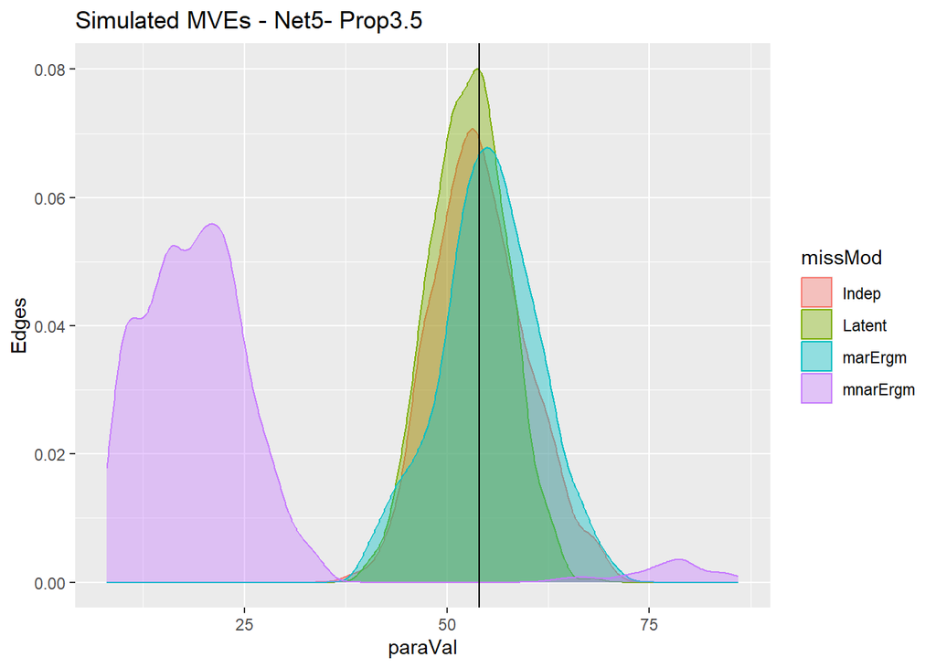

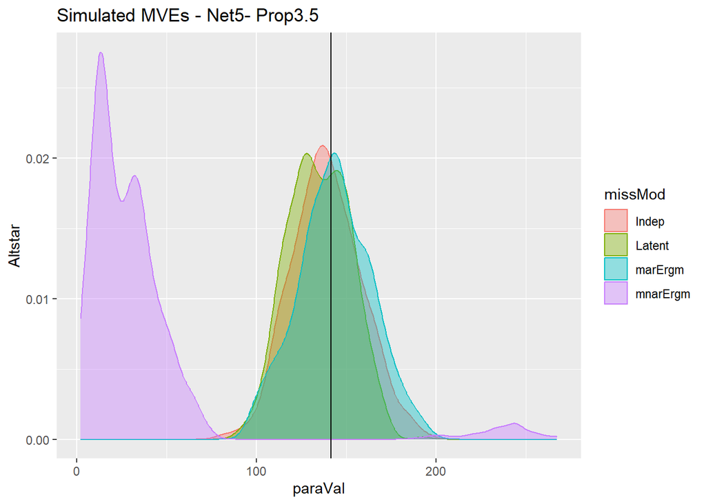

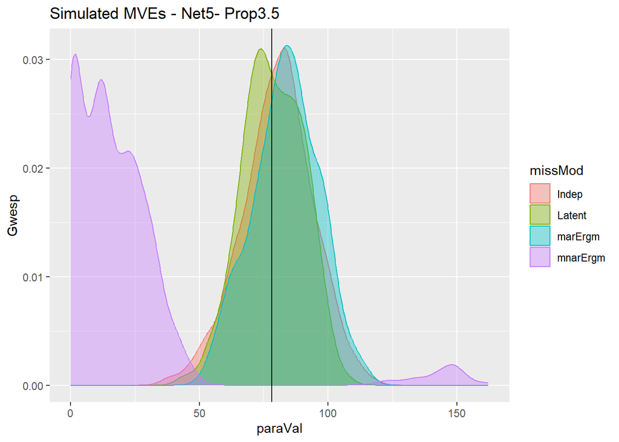

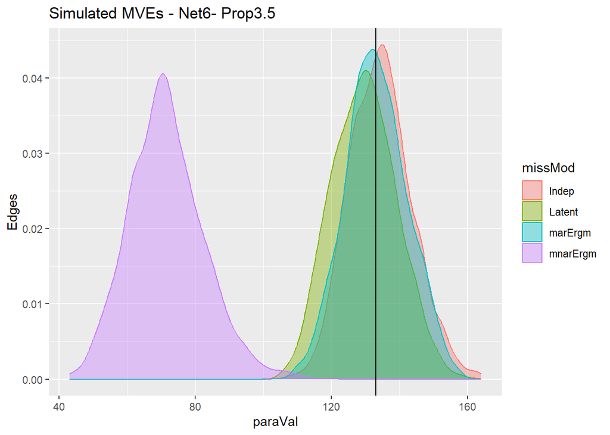

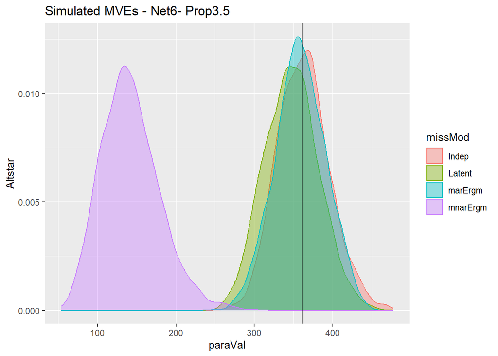

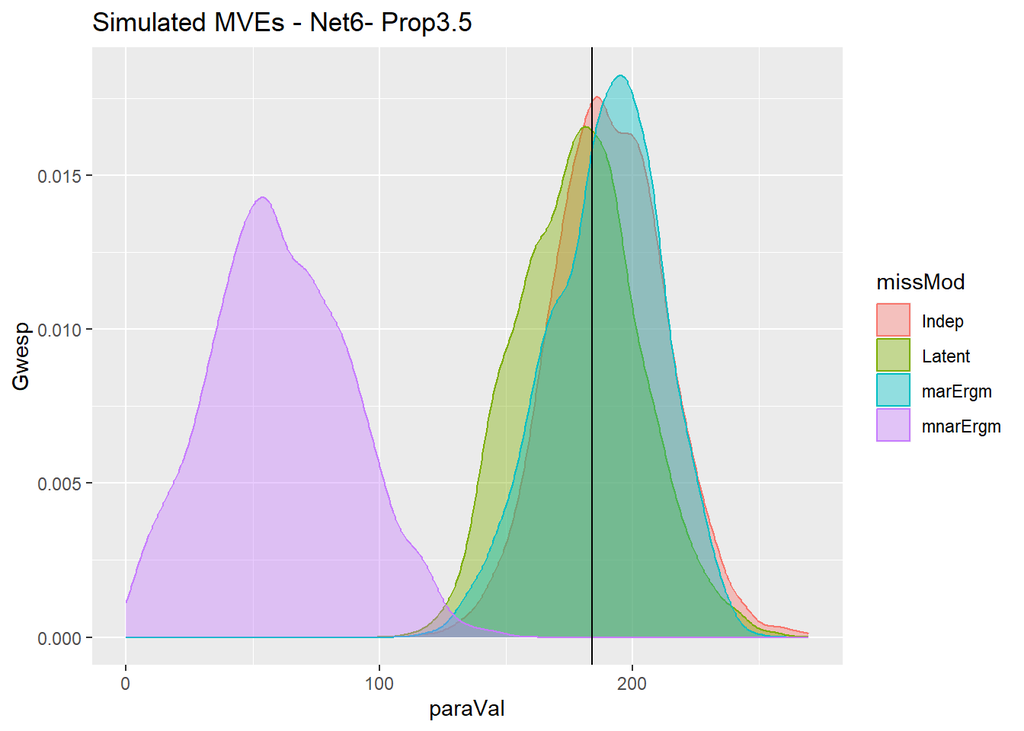

```r
# the peter output list
outputList = list.files(here("Output", "20230825_simMissReest", "Peter"))


# TODO: choose a missingness proportion (1, 3.5 or 6)
chunkMissProp = 3
chunkMissPropFloat = 3.5


# load the right set of missingness matrices
load(here("Output", "20230814_simMissNets", paste("20231024_chosenMissNets_prop", chunkMissPropFloat,".RData", sep = "")))


# now looping with a specific vector of applicable networks
# TODO: specify the UCINet networks for the chunk, these are networks with enough re-estimations
chunkNetworks = c(2, 4, 5, 6)

# TODO: vector of file names for regex
chunkRdataNames = c("20231004_missNetReest_net",
                    "20231004_missNetReest_net",
                    "20231004_missNetReest_net",
                    "20231010_missNetReest_net")


chunkMnarNames = c("20231011_missErgmNetReest_Miss",
                   "20231011_missErgmNetReest_Miss",
                   "20231011_missErgmNetReest_Miss",
                   "20231011_missErgmNetReest_Miss")

# peter mvp list and the list for missingness model identifiers
peterMvpList = list()
peterMvpMissModList = list()

# loop for all chosen networks
for(chunkInd in 1:length(chunkNetworks)){

  # make sure the re-estimation lists are empty in the beginning
  modelResList = list()
  missModelList = list()
  propMissList = list()
  trialIndList = list()

  # set a specific index for the network
  chosenNetInd = chunkNetworks[chunkInd]

  # change the 'true' network depending on the chosen network index
  trueAdj = adjMatList[[chosenNetInd]]

  # file list for the chosen network index
  chosenNetOutFiles = grep(paste(chunkRdataNames[chunkInd], chosenNetInd, sep =""), outputList)

  ## regex the MNAR files
  chosenMnarOutFiles = grep(paste(chunkMnarNames[chunkInd], "Peter", "_net", chosenNetInd, sep = ""), outputList)

  # combine the two indices
  combinedNetOutList = c(chosenNetOutFiles, chosenMnarOutFiles)

  # check to make sure there aren't any duplicates
  if( length(unique(combinedNetOutList)) != length(combinedNetOutList)){
    stop("Duplicate re-estimation datafiles! BAD.")
  }

  # loop to load
  chosenNetOutList = outputList[combinedNetOutList]

  for(fileInd in 1:length(chosenNetOutList)){
    # load all files
    load(here("Output", "20230825_simMissReest", "Peter", chosenNetOutList[fileInd]))

    # suppress these version difference warnings.
    suppressWarnings({
    modelResList[[fileInd]] = modelres$coefficients
    })

    # slight difference for the chosenMnarOutFiles because missModelList[[fileInd]] = always 4 (let 2 be mar ergm, 4 be mnar ergm)

    # this branch *should* be setting the miss model to 4 if they were regexed to be a part of the mnar list.
    if(combinedNetOutList[fileInd] %in% chosenMnarOutFiles){
     missModelList[[fileInd]] = 4
    } else {
     missModelList[[fileInd]] = as.integer(sub(".*?_missModel.*?(\\d+).*", "\\1", chosenNetOutList[[fileInd]]))
    }

    # propmiss should be the same
    propMissList[[fileInd]] = as.integer(sub(".*?_prop.*?(\\d+).*", "\\1", chosenNetOutList[[fileInd]]))


    # trial ind
    trialIndList[[fileInd]] = as.integer(sub(".*?_trial.*?(\\d+).*", "\\1", chosenNetOutList[[fileInd]]))

  }

#####

  # miss model labels
  missModelLabels = c("Indep", "marErgm", "Latent", "mnarErgm")

  # peterSims needs to be a list
  peterSimList = list()

  # a diagnostic check for the miss models chosen
  peterSimMissModList = list()

  # an absolute trial index because these lists are not going to have similar lengths.
  trial = 1

  # describe the chosen missingness matrix as a series of specific indices, net is specified above
  for(chosenMissModel in 1:length(missModelLabels)){

  # the lists contain files for all the missingness proportions, so they need to be indexed
  chosenReest = (propMissList == chunkMissProp) & (missModelList == chosenMissModel)

  modelResChosenReestList = modelResList[chosenReest]
  trialIndChosenReestList = trialIndList[chosenReest]
  missModelChosenReestList = missModelList[chosenReest]


  # OKAY, for a given missingness model, which will still iterate through all four,
  chunkTrialInds = unlist(trialIndChosenReestList)

    for(chosenTrialInd in 1:length(chunkTrialInds)){

      # and choose, needs the ACTUAL trial index, not the index for the object in the list
      chosenMissAdj = compiledMissNets[[chosenMissModel]][[chosenNetInd]][[chunkTrialInds[[chosenTrialInd]]]]

      # now for Peters, we need to manually simulate the mean value estimates.
      degradedAdj = degradeAdj(trueNet = trueAdj, missAdj = chosenMissAdj)

      # now as a network
      degradedNet = as.network(degradedAdj, directed = FALSE)

      # miss edge list
      missEdgeList = as.edgelist(as.network(chosenMissAdj, directed = FALSE))

      # model spec depends on the network
      chosenModel = degradedNet ~ edges + altkstar(2, fixed = TRUE) + gwesp(decay = log(2), fixed = TRUE)

      # if network 6, change to:
      if(chosenNetInd == 6){

      # make sure to add in attributes
      # add in attributes
        degradedNet %v% 'Age' = londonGangsAtt$Age
        degradedNet %v% 'Arrests' = londonGangsAtt$Arrests
        degradedNet %v% 'Birthplace' = londonGangsAtt$Birthplace
        degradedNet %v% 'Convictions' = londonGangsAtt$Convictions
        degradedNet %v% 'Prison' = londonGangsAtt$Prison

        chosenModel = degradedNet ~ edges + altkstar(2, fixed = TRUE) + gwesp(decay = log(2), fixed = TRUE) +
                                    nodecov('Age') +
                                    absdiff('Age') +
                                    nodecov('Arrests') +
                                    absdiff('Arrests') +
                                    nodecov('Convictions') +
                                    absdiff('Convictions') +
                                    nodematch('Prison') +
                                    nodematch('Birthplace')


      }

      peterSim = simulate(object = chosenModel,
                          constraints = ~fixallbut(missEdgeList),
                          coef = modelResChosenReestList[[chosenTrialInd]],
                          control=control.simulate(
                                    MCMC.burnin=20000,
                                    MCMC.interval=100), nsim=50)

      # shove in a list
      peterSimList[[trial]] = peterSim

      # something to keep track of which missingness model it is
      peterSimMissModList[[trial]] = chosenMissModel

      # iterate the trial index
      trial = trial + 1

    }

  }


  # and calculate MVPs

  chosenModel = "edges + altkstar(2, fixed = TRUE) + gwesp(decay = log(2), fixed = TRUE)"

  if(chunkInd == 6){
    chosenModel = "edges + altkstar(2, fixed = TRUE) + gwesp(decay = log(2), fixed = TRUE) +  nodecov('Age') +
  absdiff('Age') + nodecov('Arrests') + absdiff('Arrests') + nodecov('Convictions') + absdiff('Convictions') + nodematch('Prison') +
  nodematch('Birthplace')"
  }


  tempPeterMvpList = lapply(peterSimList, FUN = function(chosenMissMod){
      lapply(chosenMissMod, FUN = meanValPar, model = chosenModel)})

  peterMvpList[[chunkInd]] = tempPeterMvpList
  peterMvpMissModList[[chunkInd]] = peterSimMissModList

}

#### Plotting section

# the big master plot dataframe
peterMvpPlotData = data.frame(paraVal = c(), paraName = c(), missMod = c(), net = c())

# true Mvp list
trueMvpList = list()

for(chunkInd in 1:length(chunkNetworks)){

  # set a specific index for the network
  chosenNetInd = chunkNetworks[chunkInd]

  # change the 'true' network depending on the chosen network index
  trueAdj = adjMatList[[chosenNetInd]]

  # turn into a network obj
  trueNet = as.network(trueAdj, directed = FALSE)

  if(chosenNetInd == 6){
    # add in the attributes for this network/model spec
      trueNet %v% 'Age' = londonGangsAtt$Age
      trueNet %v% 'Arrests' = londonGangsAtt$Arrests
      trueNet %v% 'Birthplace' = londonGangsAtt$Birthplace
      trueNet %v% 'Convictions' = londonGangsAtt$Convictions
      trueNet %v% 'Prison' = londonGangsAtt$Prison
  }


  # plot for the 'true' MVP, put in a list for later use

  chosenModel = "edges + altkstar(2, fixed = TRUE) + gwesp(decay = log(2), fixed = TRUE)"

  # since net 6 is different,
  if(chosenNetInd == 6){
    chosenModel = "edges + altkstar(2, fixed = TRUE) + gwesp(decay = log(2), fixed = TRUE) +  nodecov('Age') +
    absdiff('Age') + nodecov('Arrests') + absdiff('Arrests') + nodecov('Convictions') + absdiff('Convictions') + nodematch('Prison') +
    nodematch('Birthplace')"
  }

  chunkTrueMvp = meanValPar(net = trueNet,
                            model = chosenModel)

  trueMvpList[[chunkInd]] = chunkTrueMvp


  # subset the right network's mvps
  chunkPeterMvp = peterMvpList[[chunkInd]]
  chunkPeterMvpMissMod = unlist(peterMvpMissModList[[chunkInd]])

  # miss models
  missMods = c("Indep", "marErgm", "Latent", "mnarErgm")

  for(chosenMissMod in 1:4){

    # chosen miss mod string
    chosenModString = missMods[chosenMissMod]

    # unlist
    tempPeterUnlisted = unlist(chunkPeterMvp[chunkPeterMvpMissMod == chosenMissMod])

    uniqueParaNames = unique(names(tempPeterUnlisted))

    # grab all the edges
    peterEdges = tempPeterUnlisted[names(tempPeterUnlisted) == uniqueParaNames[1]]

    # altstars
    peterAltstar = tempPeterUnlisted[names(tempPeterUnlisted) == uniqueParaNames[2]]

    # gwesps
    peterGwesp = tempPeterUnlisted[names(tempPeterUnlisted) == uniqueParaNames[3]]


    # using Todd (multiple miss mods)
    tempPlot = data.frame(paraVal = c(peterEdges, peterAltstar, peterGwesp),
                          paraName = c(rep("edges", length(peterEdges)), rep("Altstar", length(peterAltstar)), rep("gwesp", length(peterGwesp))),
                          missMod = rep(chosenModString, sum(length(peterEdges), length(peterAltstar), length(peterGwesp))),
                          net = rep(chosenNetInd, sum(length(peterEdges), length(peterAltstar), length(peterGwesp))))

    # bind
    peterMvpPlotData = rbind(peterMvpPlotData, tempPlot)

  }


  peterMvpPlotSubset = peterMvpPlotData %>%
    filter(paraName == "edges" & net == chosenNetInd)

  print(ggplot(peterMvpPlotSubset, aes(x = paraVal, colour = missMod, fill = missMod)) +
   # geom_histogram(alpha = 0.4, position = "identity", binwidth = 1) +
    geom_density(alpha = 0.4) +
    geom_vline(xintercept = trueMvpList[[chunkInd]][1]) +
    ylab(paste("Edges")) +
    ggtitle(label = paste("Simulated MVEs - Net", chosenNetInd, "- Prop", chunkMissPropFloat, sep = "")))

  peterMvpPlotSubset = peterMvpPlotData %>%
    filter(paraName == "Altstar" & net == chosenNetInd)

  print(ggplot(peterMvpPlotSubset, aes(x = paraVal, colour = missMod, fill = missMod)) +
   # geom_histogram(alpha = 0.4, position = "identity", binwidth = 1) +
    geom_density(alpha = 0.4) +
    geom_vline(xintercept = trueMvpList[[chunkInd]][2]) +
    ylab(paste("Altstar")) +
    ggtitle(label = paste("Simulated MVEs - Net", chosenNetInd, "- Prop", chunkMissPropFloat, sep = "")))

  peterMvpPlotSubset = peterMvpPlotData %>%
    filter(paraName == "gwesp" & net == chosenNetInd)

  print(ggplot(peterMvpPlotSubset, aes(x = paraVal, colour = missMod, fill = missMod)) +
   # geom_histogram(alpha = 0.4, position = "identity", binwidth = 1) +
    geom_density(alpha = 0.4) +
    geom_vline(xintercept = trueMvpList[[chunkInd]][3]) +
    ylab(paste("Gwesp")) +
    ggtitle(label = paste("Simulated MVEs - Net", chosenNetInd, "- Prop", chunkMissPropFloat, sep = "")))

}
```

#### 60%

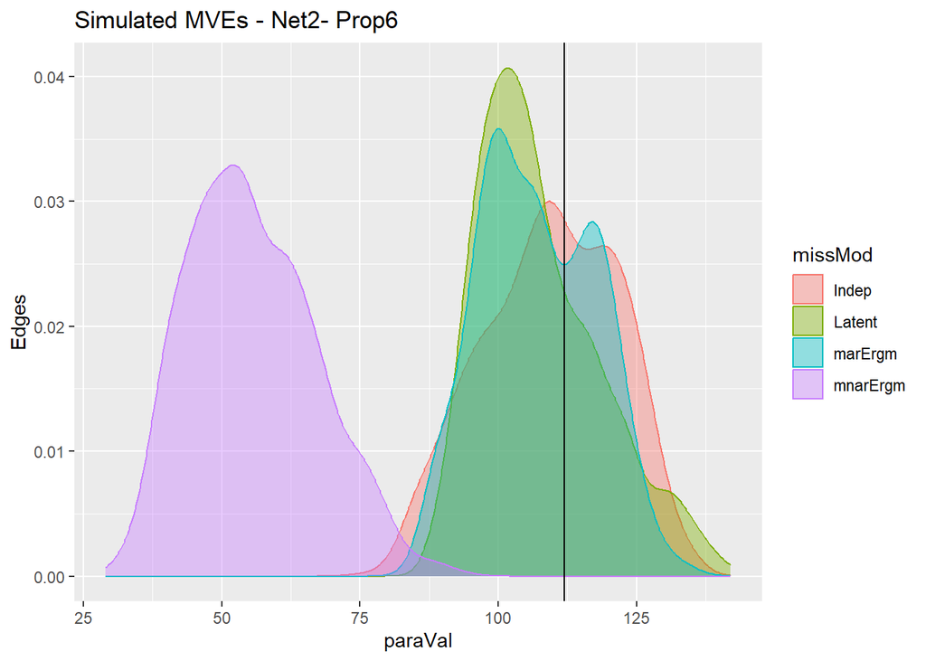

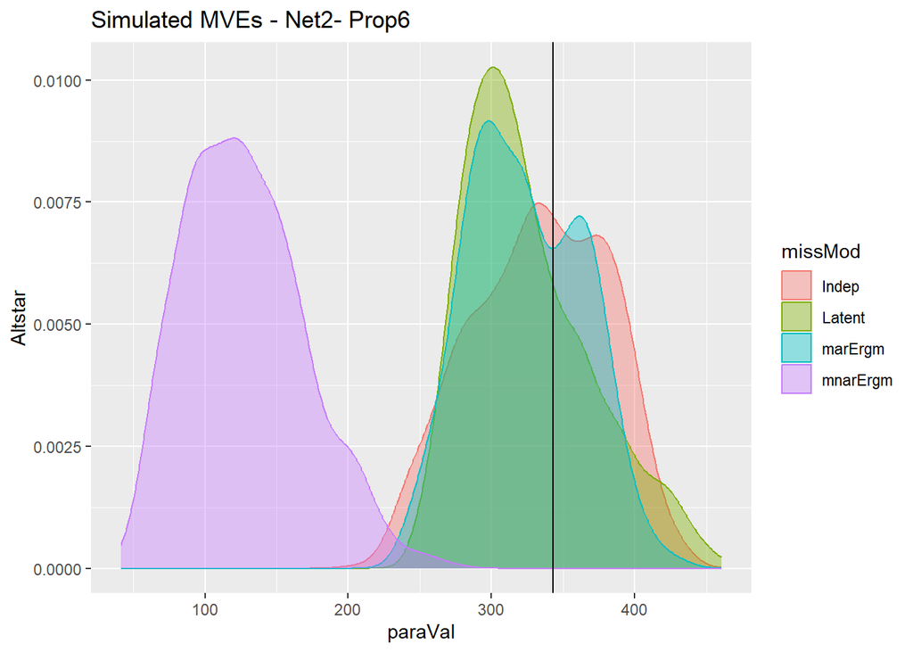

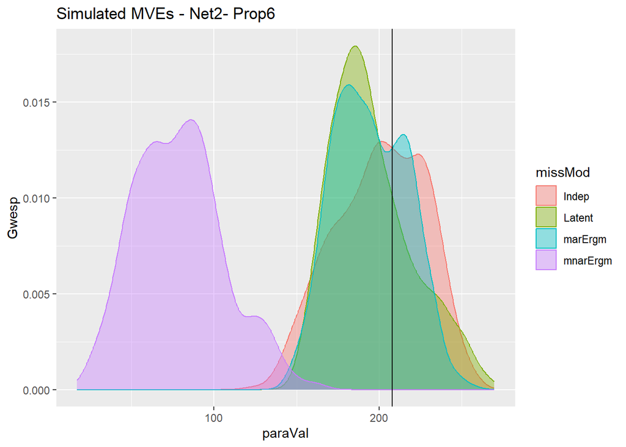

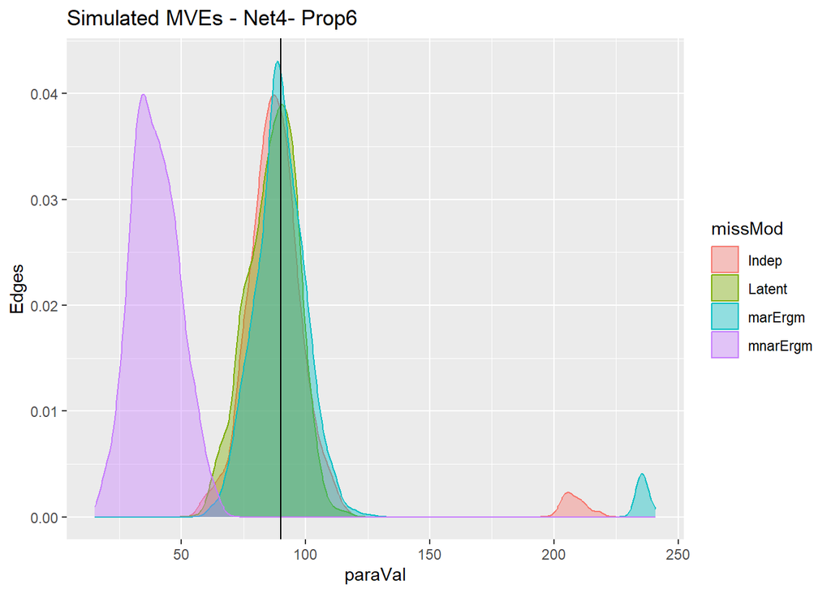

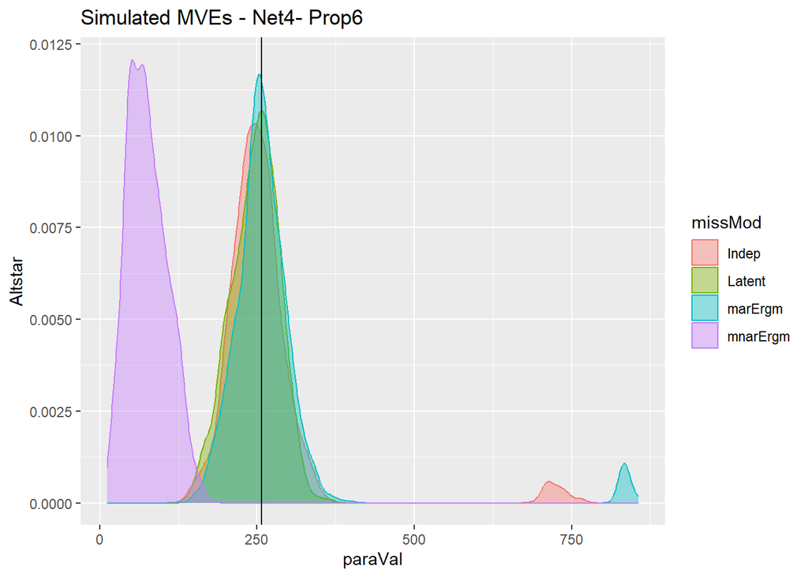

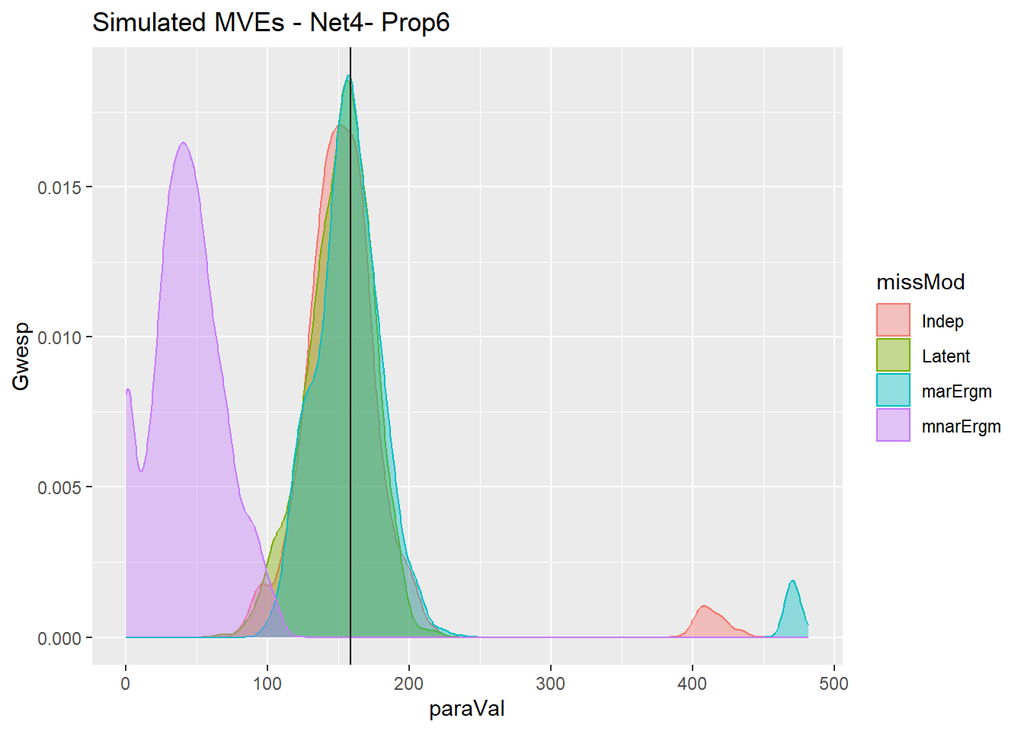

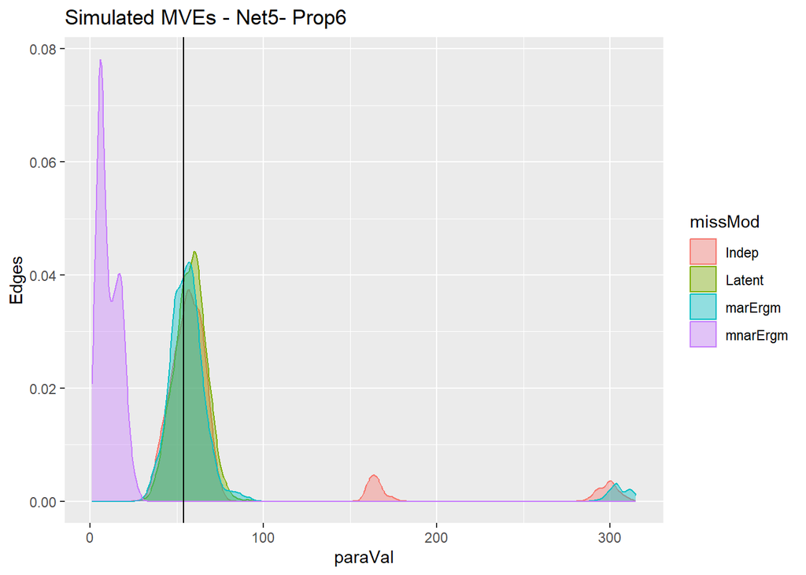

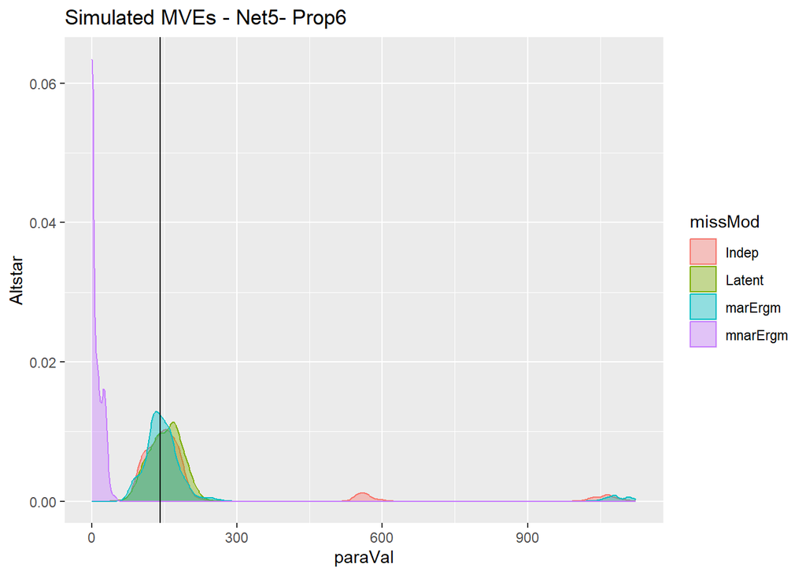

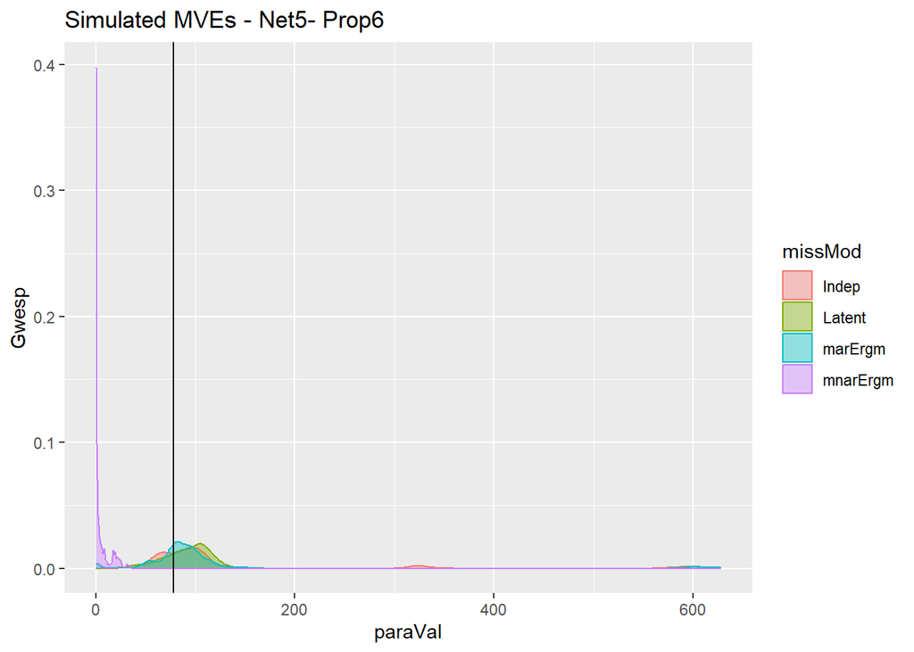

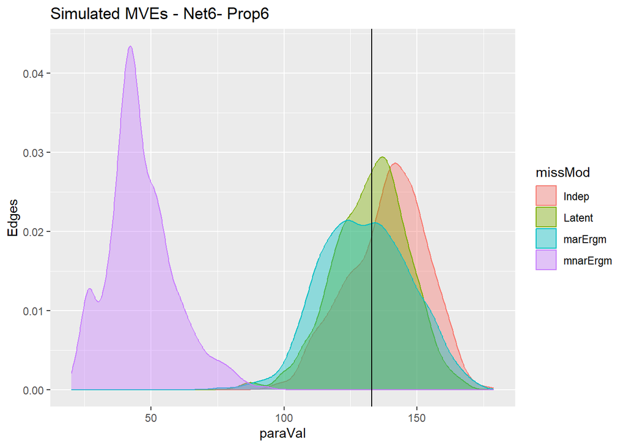

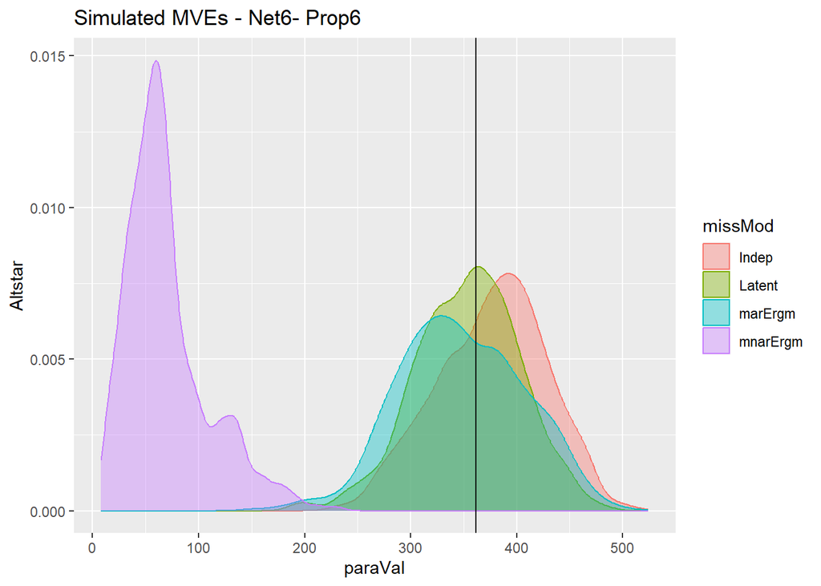

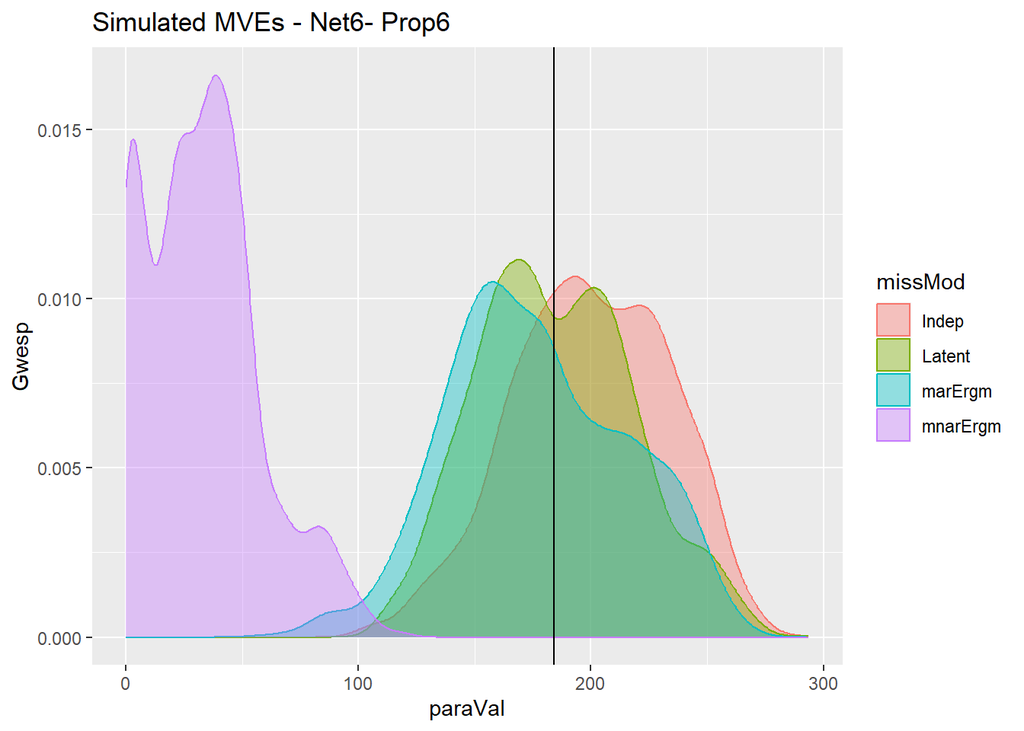

```r
# the peter output list
outputList = list.files(here("Output", "20230825_simMissReest", "Peter"))


# TODO: choose a missingness proportion (1, 3.5 or 6)
chunkMissProp = 6


# load the right set of missingness matrices
load(here("Output", "20230814_simMissNets", paste("20231024_chosenMissNets_prop", chunkMissProp,".RData", sep = "")))

# now looping with a specific vector of applicable networks
# TODO: specify the UCINet networks for the chunk, these are networks with enough re-estimations
chunkNetworks = c(2, 4, 5, 6)

# TODO: vector of file names for regex
chunkRdataNames = c("20231005_missNetReest_net",
                    "20231005_missNetReest_net",
                    "20231011_missNetReest_net",
                    "20231011_missNetReest_net")

chunkMnarNames = c("20231012_missErgmNetReest_Miss",
                   "20231012_missErgmNetReest_Miss",
                   "20231012_missErgmNetReest_Miss",
                   "20231012_missErgmNetReest_Miss")


# peter mvp list and the list for missingness model identifiers
peterMvpList = list()
peterMvpMissModList = list()

# loop for all chosen networks
for(chunkInd in 1:length(chunkNetworks)){

  # make sure the re-estimation lists are empty in the beginning
  modelResList = list()
  missModelList = list()
  propMissList = list()
  trialIndList = list()

  # set a specific index for the network
  chosenNetInd = chunkNetworks[chunkInd]

  # change the 'true' network depending on the chosen network index
  trueAdj = adjMatList[[chosenNetInd]]

  # file list for the chosen network index
  chosenNetOutFiles = grep(paste(chunkRdataNames[chunkInd], chosenNetInd, sep =""), outputList)

  ## regex the MNAR files
  chosenMnarOutFiles = grep(paste(chunkMnarNames[chunkInd], "Peter", "_net", chosenNetInd, sep = ""), outputList)

  # combine the two indices
  combinedNetOutList = c(chosenNetOutFiles, chosenMnarOutFiles)

  # check to make sure there aren't any duplicates
  if( length(unique(combinedNetOutList)) != length(combinedNetOutList)){
    stop("Duplicate re-estimation datafiles! BAD.")
  }

  # loop to load
  chosenNetOutList = outputList[combinedNetOutList]

  for(fileInd in 1:length(chosenNetOutList)){
    # load all files
    load(here("Output", "20230825_simMissReest", "Peter", chosenNetOutList[fileInd]))

    # suppress these version difference warnings.
    suppressWarnings({
    modelResList[[fileInd]] = modelres$coefficients
    })

    # slight difference for the chosenMnarOutFiles because missModelList[[fileInd]] = always 4 (let 2 be mar ergm, 4 be mnar ergm)

    # this branch *should* be setting the miss model to 4 if they were regexed to be a part of the mnar list.
    if(combinedNetOutList[fileInd] %in% chosenMnarOutFiles){
     missModelList[[fileInd]] = 4
    } else {
     missModelList[[fileInd]] = as.integer(sub(".*?_missModel.*?(\\d+).*", "\\1", chosenNetOutList[[fileInd]]))
    }

    # propmiss should be the same
    propMissList[[fileInd]] = as.integer(sub(".*?_prop.*?(\\d+).*", "\\1", chosenNetOutList[[fileInd]]))


    # trial ind
    trialIndList[[fileInd]] = as.integer(sub(".*?_trial.*?(\\d+).*", "\\1", chosenNetOutList[[fileInd]]))

  }

#####

  # miss model labels
  missModelLabels = c("Indep", "marErgm", "Latent", "mnarErgm")

  # peterSims needs to be a list
  peterSimList = list()

  # a diagnostic check for the miss models chosen
  peterSimMissModList = list()

  # an absolute trial index because these lists are not going to have similar lengths.
  trial = 1

  # describe the chosen missingness matrix as a series of specific indices, net is specified above
  for(chosenMissModel in 1:length(missModelLabels)){

  # the lists contain files for all the missingness proportions, so they need to be indexed
  chosenReest = (propMissList == chunkMissProp) & (missModelList == chosenMissModel)

  modelResChosenReestList = modelResList[chosenReest]
  trialIndChosenReestList = trialIndList[chosenReest]
  missModelChosenReestList = missModelList[chosenReest]


  # OKAY, for a given missingness model, which will still iterate through all four,
  chunkTrialInds = unlist(trialIndChosenReestList)

    for(chosenTrialInd in 1:length(chunkTrialInds)){

      # and choose, needs the ACTUAL trial index, not the index for the object in the list
      chosenMissAdj = compiledMissNets[[chosenMissModel]][[chosenNetInd]][[chunkTrialInds[[chosenTrialInd]]]]

      # now for Peters, we need to manually simulate the mean value estimates.
      degradedAdj = degradeAdj(trueNet = trueAdj, missAdj = chosenMissAdj)

      # now as a network
      degradedNet = as.network(degradedAdj, directed = FALSE)

      # miss edge list
      missEdgeList = as.edgelist(as.network(chosenMissAdj, directed = FALSE))

      # model spec depends on the network
      chosenModel = degradedNet ~ edges + altkstar(2, fixed = TRUE) + gwesp(decay = log(2), fixed = TRUE)

      # if network 6, change to:
      if(chosenNetInd == 6){

      # make sure to add in attributes
      # add in attributes
        degradedNet %v% 'Age' = londonGangsAtt$Age
        degradedNet %v% 'Arrests' = londonGangsAtt$Arrests
        degradedNet %v% 'Birthplace' = londonGangsAtt$Birthplace
        degradedNet %v% 'Convictions' = londonGangsAtt$Convictions
        degradedNet %v% 'Prison' = londonGangsAtt$Prison

        chosenModel = degradedNet ~ edges + altkstar(2, fixed = TRUE) + gwesp(decay = log(2), fixed = TRUE) +
                                    nodecov('Age') +
                                    absdiff('Age') +
                                    nodecov('Arrests') +
                                    absdiff('Arrests') +
                                    nodecov('Convictions') +
                                    absdiff('Convictions') +
                                    nodematch('Prison') +
                                    nodematch('Birthplace')


      }

      peterSim = simulate(object = chosenModel,
                          constraints = ~fixallbut(missEdgeList),
                          coef = modelResChosenReestList[[chosenTrialInd]],
                          control=control.simulate(
                                    MCMC.burnin=20000,
                                    MCMC.interval=100), nsim=50)

      # shove in a list
      peterSimList[[trial]] = peterSim

      # something to keep track of which missingness model it is
      peterSimMissModList[[trial]] = chosenMissModel

      # iterate the trial index
      trial = trial + 1

    }

  }


  # and calculate MVPs

  chosenModel = "edges + altkstar(2, fixed = TRUE) + gwesp(decay = log(2), fixed = TRUE)"

  if(chunkInd == 6){
    chosenModel = "edges + altkstar(2, fixed = TRUE) + gwesp(decay = log(2), fixed = TRUE) +  nodecov('Age') +
  absdiff('Age') + nodecov('Arrests') + absdiff('Arrests') + nodecov('Convictions') + absdiff('Convictions') + nodematch('Prison') +
  nodematch('Birthplace')"
  }


  tempPeterMvpList = lapply(peterSimList, FUN = function(chosenMissMod){
      lapply(chosenMissMod, FUN = meanValPar, model = chosenModel)})

  peterMvpList[[chunkInd]] = tempPeterMvpList
  peterMvpMissModList[[chunkInd]] = peterSimMissModList

}

#### Plotting section

# the big master plot dataframe
peterMvpPlotData = data.frame(paraVal = c(), paraName = c(), missMod = c(), net = c())

# true Mvp list
trueMvpList = list()

for(chunkInd in 1:length(chunkNetworks)){

  # set a specific index for the network
  chosenNetInd = chunkNetworks[chunkInd]

  # change the 'true' network depending on the chosen network index
  trueAdj = adjMatList[[chosenNetInd]]

  # turn into a network obj
  trueNet = as.network(trueAdj, directed = FALSE)

  if(chosenNetInd == 6){
    # add in the attributes for this network/model spec
      trueNet %v% 'Age' = londonGangsAtt$Age
      trueNet %v% 'Arrests' = londonGangsAtt$Arrests
      trueNet %v% 'Birthplace' = londonGangsAtt$Birthplace
      trueNet %v% 'Convictions' = londonGangsAtt$Convictions
      trueNet %v% 'Prison' = londonGangsAtt$Prison
  }


  # plot for the 'true' MVP, put in a list for later use

  chosenModel = "edges + altkstar(2, fixed = TRUE) + gwesp(decay = log(2), fixed = TRUE)"

  # since net 6 is different,
  if(chosenNetInd == 6){
    chosenModel = "edges + altkstar(2, fixed = TRUE) + gwesp(decay = log(2), fixed = TRUE) +  nodecov('Age') +
    absdiff('Age') + nodecov('Arrests') + absdiff('Arrests') + nodecov('Convictions') + absdiff('Convictions') + nodematch('Prison') +
    nodematch('Birthplace')"
  }

  chunkTrueMvp = meanValPar(net = trueNet,
                            model = chosenModel)

  trueMvpList[[chunkInd]] = chunkTrueMvp


  # subset the right network's mvps
  chunkPeterMvp = peterMvpList[[chunkInd]]
  chunkPeterMvpMissMod = unlist(peterMvpMissModList[[chunkInd]])

  # miss models
  missMods = c("Indep", "marErgm", "Latent", "mnarErgm")

  for(chosenMissMod in 1:4){

    # chosen miss mod string
    chosenModString = missMods[chosenMissMod]

    # unlist
    tempPeterUnlisted = unlist(chunkPeterMvp[chunkPeterMvpMissMod == chosenMissMod])

    uniqueParaNames = unique(names(tempPeterUnlisted))

    # grab all the edges
    peterEdges = tempPeterUnlisted[names(tempPeterUnlisted) == uniqueParaNames[1]]

    # altstars
    peterAltstar = tempPeterUnlisted[names(tempPeterUnlisted) == uniqueParaNames[2]]

    # gwesps
    peterGwesp = tempPeterUnlisted[names(tempPeterUnlisted) == uniqueParaNames[3]]


    # using Todd (multiple miss mods)
    tempPlot = data.frame(paraVal = c(peterEdges, peterAltstar, peterGwesp),
                          paraName = c(rep("edges", length(peterEdges)), rep("Altstar", length(peterAltstar)), rep("gwesp", length(peterGwesp))),
                          missMod = rep(chosenModString, sum(length(peterEdges), length(peterAltstar), length(peterGwesp))),
                          net = rep(chosenNetInd, sum(length(peterEdges), length(peterAltstar), length(peterGwesp))))

    # bind
    peterMvpPlotData = rbind(peterMvpPlotData, tempPlot)

  }


  peterMvpPlotSubset = peterMvpPlotData %>%
    filter(paraName == "edges" & net == chosenNetInd)

  print(ggplot(peterMvpPlotSubset, aes(x = paraVal, colour = missMod, fill = missMod)) +
   # geom_histogram(alpha = 0.4, position = "identity", binwidth = 1) +
    geom_density(alpha = 0.4) +
    geom_vline(xintercept = trueMvpList[[chunkInd]][1]) +
    ylab(paste("Edges")) +
    ggtitle(label = paste("Simulated MVEs - Net", chosenNetInd, "- Prop", chunkMissProp, sep = "")))

  peterMvpPlotSubset = peterMvpPlotData %>%
    filter(paraName == "Altstar" & net == chosenNetInd)

  print(ggplot(peterMvpPlotSubset, aes(x = paraVal, colour = missMod, fill = missMod)) +
   # geom_histogram(alpha = 0.4, position = "identity", binwidth = 1) +
    geom_density(alpha = 0.4) +
    geom_vline(xintercept = trueMvpList[[chunkInd]][2]) +
    ylab(paste("Altstar")) +
    ggtitle(label = paste("Simulated MVEs - Net", chosenNetInd, "- Prop", chunkMissProp, sep = "")))

  peterMvpPlotSubset = peterMvpPlotData %>%
    filter(paraName == "gwesp" & net == chosenNetInd)

  print(ggplot(peterMvpPlotSubset, aes(x = paraVal, colour = missMod, fill = missMod)) +
   # geom_histogram(alpha = 0.4, position = "identity", binwidth = 1) +
    geom_density(alpha = 0.4) +
    geom_vline(xintercept = trueMvpList[[chunkInd]][3]) +
    ylab(paste("Gwesp")) +
    ggtitle(label = paste("Simulated MVEs - Net", chosenNetInd, "- Prop", chunkMissProp, sep = "")))

}
```

```r
# plotting the degraded metrics with the 'true' value
# and indexing which coefficients are used
# ... and what type of missingness it is...
# ... with indices for what network dataset and the proportion of missingness....

# initial code for making the plot data, turned into a function
# # extracting specific metrics
# uniqueMetrics = unique(names(unlist(degradedNetMetrics[[1]])))
#
# # initialise plot data
# metricPlotData = data.frame(metricName = NA, varyingParameter = NA, parameterValue = NA, quant0.05 = NA, median = NA, quant0.95 = NA)
#
# # additional list for metric ranges
# rawMetricList = list()
#
# # loop to choose different metrics in calculating the different quantiles
# for(chosenMetric in 1:length(uniqueMetrics)){
#
#   # a value for the row index based on the iteration of the loop
#   tempRowInd = seq(from = 1 + (length(degradedNetMetrics) * (chosenMetric - 1)), to = chosenMetric * length(degradedNetMetrics))
#
#   # fix this value for now, but this would depend on the model spec and which chosen para it is
#   chosenParaLabel = "gwdeg"
#   metricPlotData[tempRowInd,"varyingParameter"] = chosenParaLabel
#
#   # put in the metric name
#   metricPlotData[tempRowInd, "metricName"] = uniqueMetrics[chosenMetric]
#
#   # extract the chosen metrics from the nested list
#   rawMetricList[[chosenMetric]] = lapply(degradedNetMetrics, function(chosenParaVal){unlist(chosenParaVal)[names(unlist(chosenParaVal)) == uniqueMetrics[[chosenMetric]]]})
#
#   # fill in the quantiles
#   metricPlotData[tempRowInd, c("quant0.05", "median", "quant0.95")] = do.call(rbind, lapply(rawMetricList[[chosenMetric]], function(chosenParaVal){quantile(chosenParaVal, c(0.05, 0.5, 0.95))}))
#
#   # lastly, give the parameter values
#   metricPlotData[tempRowInd, "parameterValue"] = paraRange
# }

## Function to prep metric plot data
prepMetricPlot = function(degradedNetMetricList, chosenPara){

  ## prepMetricPlot(degradedNetMetricList, chosenPara) takes a list of metric calculated from degraded networks
  ## and a specified parameter name that controlled the degradation to subset them into a data frame to be used
  ## for plotting purposes.
  ##
  ## Input:
  ## - degradedNetMetricList: A list of (nested) network metrics calculated using the netMetrics function on
  ##                          a list of degraded networks. Missingness needs to be saved as 0 for values to calculable.
  ##
  ## - chosenPara: A string to describe which parameter is being varied in the degradation of the networks.
  ##
  ## Output:
  ## - A dataframe containing the metric names, which parameter is being varied and what its value is for the degradation,
  ##   and three quantiles (5, 50, and 95) to describe the range and median of the degraded metric.


  # extracting specific metrics
  uniqueMetrics = unique(names(unlist(degradedNetMetricList[[1]])))

  # initialise plot data
  metricPlotData = data.frame(metricName = NA, varyingParameter = NA, parameterValue = NA, quant0.05 = NA, median = NA, quant0.95 = NA)

  # additional list for metric ranges
  rawMetricList = list()

  # loop to choose different metrics in calculating the different quantiles
  for(chosenMetric in 1:length(uniqueMetrics)){

    # a value for the row index based on the iteration of the loop
    tempRowInd = seq(from = 1 + (length(degradedNetMetricList) * (chosenMetric - 1)), to = chosenMetric * length(degradedNetMetricList))

    # fix this value for now, but this would depend on the model spec and which chosen para it is
    chosenParaLabel = chosenPara
    metricPlotData[tempRowInd,"varyingParameter"] = chosenParaLabel

    # put in the metric name
    metricPlotData[tempRowInd, "metricName"] = uniqueMetrics[chosenMetric]

    # extract the chosen metrics from the nested list
    rawMetricList[[chosenMetric]] = lapply(degradedNetMetricList, function(chosenParaVal){unlist(chosenParaVal)[names(unlist(chosenParaVal)) == uniqueMetrics[[chosenMetric]]]})

    # fill in the quantiles
    metricPlotData[tempRowInd, c("quant0.05", "median", "quant0.95")] = do.call(rbind, lapply(rawMetricList[[chosenMetric]], function(chosenParaVal){quantile(chosenParaVal, c(0.05, 0.5, 0.95))}))

    # lastly, give the parameter values
    metricPlotData[tempRowInd, "parameterValue"] = paraRange
  }

  # return the plot data
  return(metricPlotData)
}

metricPlotData = prepMetricPlot(degradedNetMetricList = degradedNetMetrics, chosenPara = "gwdeg")

# unqiue metric names
uniqueMetrics = unique(names(unlist(degradedNetMetrics[[1]])))

## now that the data's right, it's just a matter of plotting-
metricPlotData %>%
  filter(metricName == "clustering") %>%
  ggplot(aes(x = parameterValue, y = median)) +
  geom_line() +
  geom_ribbon(aes(ymin = quant0.05, ymax = quant0.95), alpha = 0.2) +
  labs(title = "Metric diagnostics - varyingGwdeg - Prop1 - Miss0") +
  xlab("gwdeg value") +
  ylab("Clustering")

# note: the chosen missingness will always be 0 because calculating metrics needs missingness to be 0, so take it off the plot title

## Turn this base plot code into a function-
missMetricPlot = function(data, chosenMetric, chosenPara, chosenProp){

  ## missMetricPlot(data, chosenMetric, chosenPara, chosenProp) is a very specialised plotting function that
  ## produces a caterpillar plot to compare parameter estimates for very specific data.
  ##
  ## Input:
  ## - data: A data frame containing the metric name, varying parameter, the varying parameter's value, and
  ##         5th, 50th, and 95th quantiles of the metric. Obtained from prepMetricPlot().
  ##
  ## - chosenPara: A string to describe which parameter is being varied in the degradation of the networks.
  ##
  ## - chosenProp: A single integer or float with three options representing the proportion of missingness.
  ##               Options are 1 = 10%, 3.5 = 35%, 6 = 60%.
  ##
  ## Output:
  ## - The output should be a line plot with a shaded area representing the 90% confidence interval of the metric.
  ##   Its labels should be adaptive to the chosen metric, (varying) parameter, and proportion of missingness.


  # requires ggplot2 and dplyr
  require(ggplot2)
  require(dplyr)

  # and plot
  data %>%
  filter(metricName == chosenMetric) %>%
  ggplot(aes(x = parameterValue, y = median)) +
  geom_line() +
  geom_ribbon(aes(ymin = quant0.05, ymax = quant0.95), alpha = 0.2) +
  labs(title = paste("Depleted network diagnostics - varying", chosenPara," - Prop", chosenProp, sep = "")) +
  xlab(paste("Varying", chosenPara, "value")) +
  ylab(paste(toupper(substr(chosenMetric, 1, 1)), substr(chosenMetric, 2, nchar(chosenMetric)), sep = ""))

}


# do this for all the unique metrics
missMetricPlot(data = metricPlotData, chosenMetric = uniqueMetrics[2], chosenPara = "Gwdeg", chosenProp = 1)
missMetricPlot(data = metricPlotData, chosenMetric = uniqueMetrics[3], chosenPara = "Gwdeg", chosenProp = 1)
missMetricPlot(data = metricPlotData, chosenMetric = uniqueMetrics[4], chosenPara = "Gwdeg", chosenProp = 1)


### and now the mean value parameterisations
# a check to make sure it works
meanValPar(net = degradedNetList[[4]][[10]],
           model = "edges + gwdegree(decay = log(2), fixed = TRUE) + gwesp(decay = log(2), fixed = TRUE)")

# mass apply to lists
meanValParLists = lapply(degradedNetList, function(chosenParaVal){
  lapply(chosenParaVal, meanValPar, model = "edges + gwdegree(decay = log(2), fixed = TRUE) + gwesp(decay = log(2), fixed = TRUE)")
})

# unlist them to plot
meanValParUnlisted = lapply(meanValParLists, unlist)

### commented out section is for code that is largely identical to the function to prep plot data above
# # initialise plot data
# meanValPlotData = data.frame(parameterName = NA, varyingParameter = NA, parameterValue = NA, quant0.05 = NA, median = NA, quant0.95 = NA)
#
# # additional list for metric ranges
# rawMeanValList = list()
#
# # grab unique parameter names
# uniqueParaNames = unique(names(meanValParUnlisted[[1]]))
#
# # loop to grab the quantiles of each of these mean value parameterisation values for each parameter
# for(chosenParaName in 1:length(uniqueParaNames)){
#
#   # a value for the row index based on the iteration of the loop
#   tempRowInd = seq(from = 1 + (length(meanValParUnlisted) * (chosenParaName - 1)), to = chosenParaName * length(meanValParUnlisted))
#
#   # fix this value for now, but this would depend on the model spec and which chosen para it is
#   chosenParaLabel = "gwdeg"
#   meanValPlotData[tempRowInd,"varyingParameter"] = chosenParaLabel
#
#   # put in the metric name
#   meanValPlotData[tempRowInd, "parameterName"] = uniqueParaNames[chosenParaName]
#
#   # extract the chosen metrics from the nested list
#   rawMeanValList[[chosenParaName]] = lapply(meanValParLists, function(chosenParaVal){unlist(chosenParaVal)[names(unlist(chosenParaVal)) == uniqueParaNames[[chosenParaName]]]})
#
#   # fill in the quantiles
#   meanValPlotData[tempRowInd, c("quant0.05", "median", "quant0.95")] = do.call(rbind, lapply(rawMeanValList[[chosenParaName]], function(chosenParaVal){quantile(chosenParaVal, c(0.05, 0.5, 0.95))}))
#
#   # lastly, give the parameter values
#   meanValPlotData[tempRowInd, "parameterValue"] = paraRange
# }

## if I consider the mean value parametrisations as another metric, I don't need another chunk of code specifically for these
meanValPlotData = prepMetricPlot(degradedNetMetricList = meanValParUnlisted, chosenPara = "gwdeg")

# check all unique parameter names
uniqueParaNames = unique(names(meanValParUnlisted[[1]]))

# and check to make sure the plots work
missMetricPlot(data = meanValPlotData, chosenMetric = uniqueParaNames[1], chosenPara = "Gwdeg", chosenProp = 1)
missMetricPlot(data = meanValPlotData, chosenMetric = uniqueParaNames[2], chosenPara = "Gwdeg", chosenProp = 1)
missMetricPlot(data = meanValPlotData, chosenMetric = uniqueParaNames[3], chosenPara = "Gwdeg", chosenProp = 1)
```